# Model Terbaik ARIMA

Sausan

2025-02-25

# Import Library Yang Dibutuhkan

```r
library("visdat")
```

```r
library(ggplot2)
library(astsa)
library(tseries)
library(forecast)
library(TSA)
library(TSA)
library(quantmod)
library(rugarch)
library(MLmetrics)
library(FinTS)
library(moments)
```

# Import Dataset

```r
UNVRJK <- read.csv("C:/Users/LENOVO/Documents/SMT 7/PENULISAN PROPOSAL/UNVR.JK 2014-2025.csv")
head(UNVRJK)
```

```
##         Date Open High  Low Close Adj.Close   Volume
## 1 2014-01-02 5280 5360 5280  5360  3910.367  6175000
## 2 2014-01-03 5290 5360 5240  5300  3866.594  8817500
## 3 2014-01-06 5360 5360 5280  5350  3903.071  6357500
## 4 2014-01-07 5350 5360 5240  5240  3822.821  7055500
## 5 2014-01-08 5280 5315 5185  5240  3822.821 10381500
## 6 2014-01-09 5210 5285 5185  5215  3804.582  9274500
```

```r
tail(UNVRJK)
```

```
##            Date Open High  Low Close Adj.Close   Volume
## 2714 2024-12-19 1795 1795 1760  1770      1770  6313900
## 2715 2024-12-20 1770 1785 1750  1750      1750 16051300
## 2716 2024-12-23 1765 1795 1755  1785      1785  5679500
## 2717 2024-12-24 1785 1820 1780  1780      1780  3695800
## 2718 2024-12-27 1785 1860 1780  1840      1840  9226300
## 2719 2024-12-30 1840 1890 1820  1885      1885  9186900
```

# EDA

```r
#Melihat dimensi data
dim(UNVRJK)
```

```
## [1] 2719    7
```

```r
#Melihat struktur dataset
str(UNVRJK)
```

```
## 'data.frame':    2719 obs. of  7 variables:
##  $ Date     : chr  "2014-01-02" "2014-01-03" "2014-01-06" "2014-01-07" ...
##  $ Open     : num  5280 5290 5360 5350 5280 ...
##  $ High     : num  5360 5360 5360 5360 5315 ...
##  $ Low      : num  5280 5240 5280 5240 5185 ...
##  $ Close    : num  5360 5300 5350 5240 5240 ...
##  $ Adj.Close: num  3910 3867 3903 3823 3823 ...
##  $ Volume   : int  6175000 8817500 6357500 7055500 10381500 9274500 11790500 17524000 27483000 11031000 ...
```

```r
#Mengecek missing value data
sapply(UNVRJK, function (x) sum(is.na(x)))
```

```
##      Date      Open      High       Low     Close Adj.Close    Volume
##         0         0         0         0         0         0         0
```

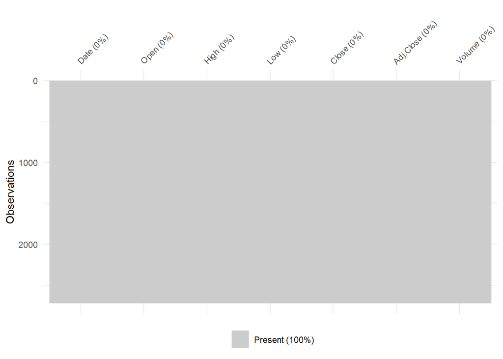

```r
#visualisasi missing value
vis_miss(UNVRJK)
```

# EDA

```r
#Analisis Deskriptif
summary(UNVRJK)
```

```
##      Date                Open            High            Low
##  Length:2719        Min.   : 1745   Min.   : 1770   Min.   : 1735
##  Class :character   1st Qu.: 4690   1st Qu.: 4740   1st Qu.: 4615
##  Mode  :character   Median : 7400   Median : 7500   Median : 7325
##                     Mean   : 6833   Mean   : 6900   Mean   : 6756
##                     3rd Qu.: 8830   3rd Qu.: 8900   3rd Qu.: 8732
##                     Max.   :11235   Max.   :11620   Max.   :11180
##      Close         Adj.Close        Volume
##  Min.   : 1735   Min.   :1698   Min.   :        0
##  1st Qu.: 4690   1st Qu.:4108   1st Qu.:  6814000
##  Median : 7400   Median :5832   Median : 10222500
##  Mean   : 6828   Mean   :5528   Mean   : 13724350
##  3rd Qu.: 8832   3rd Qu.:6963   3rd Qu.: 15960000
##  Max.   :11180   Max.   :8829   Max.   :250903800
```

# Plot Agregasi

# Boxplot untuk melihat outlier

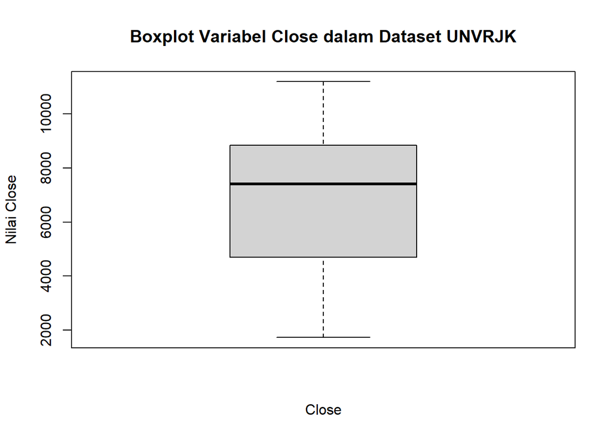

```r
boxplot(UNVRJK$Close,
        main = "Boxplot Variabel Close dalam Dataset UNVRJK",
        xlab = "Close", ylab = "Nilai Close")
```

Berdasarkan output boxplot di atas terlihat bahwa tidak terdapat outlier

# Feature Selection

```r
#Ambil Data
Close <- ts(UNVRJK[,5])
head(Close)
```

```
## Time Series:
## Start = 1
## End = 6
## Frequency = 1
## [1] 5360 5300 5350 5240 5240 5215
```

# Plot Time Series

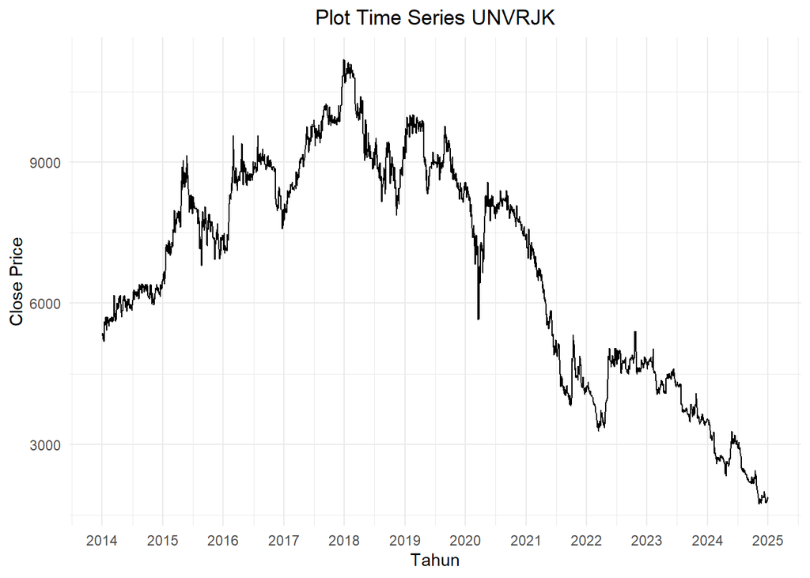

```r
UNVRJK$Date <- as.Date(UNVRJK$Date)
ggplot(UNVRJK, aes(x = Date, y = Close)) +
  geom_line() +
  labs(title = "Plot Time Series UNVRJK", x = "Tahun", y = "Close Price") +
  scale_x_date(date_breaks = "1 year", date_labels = "%Y") +
  theme_minimal() +
  theme(plot.title = element_text(hjust = 0.5))  # Menengahkan judul
```

## Kesimpulan Plot Time Series

Dari gambar di atas dapat diketahui bahwa perkembangan harga saham dalam 10 tahun terakhir cukup fluktuatif. Maksud fluktuatif mengindikasikan adanya variasi/perubahan yang signifikan dalam harga saham dari waktu ke waktu. Sehingga dapat disimpulkan bahwa harga saham telah mengalami perubahan yang signifikan selama periode 10 tahun terakhir tanpa memberikan detail spesifik tentang arah/pola fluktuasi tersebut.

# Uji Stationeritas

## Cek Stationeritas Terhadap Ragam

```r
bc = BoxCox.lambda(Close)
bc
```

```
## [1] 0.3854476
```

Pada output diatas terlihat hasil nilai λ menunjukkan angka 0.3854476 (Jauh dari 1). Jadi dapat disimpulkan bahwa data tersebut tidak stasioner secara ragam.

## Cek Stasioneritas Terhadap Rata-Rata/Rataan

```r
adf.test(Close)
```

```
##
##  Augmented Dickey-Fuller Test
##
## data:  Close
## Dickey-Fuller = -1.8956, Lag order = 13, p-value = 0.6225
## alternative hypothesis: stationary
```

Pada output diatas terlihat pada uji ADF diperoleh p-values lebih besar dari nilai α (0.6225>0,05) sehingga H0 diterima yang berarti data tidak stationer secara rataan

## Plot ACF dan PACF

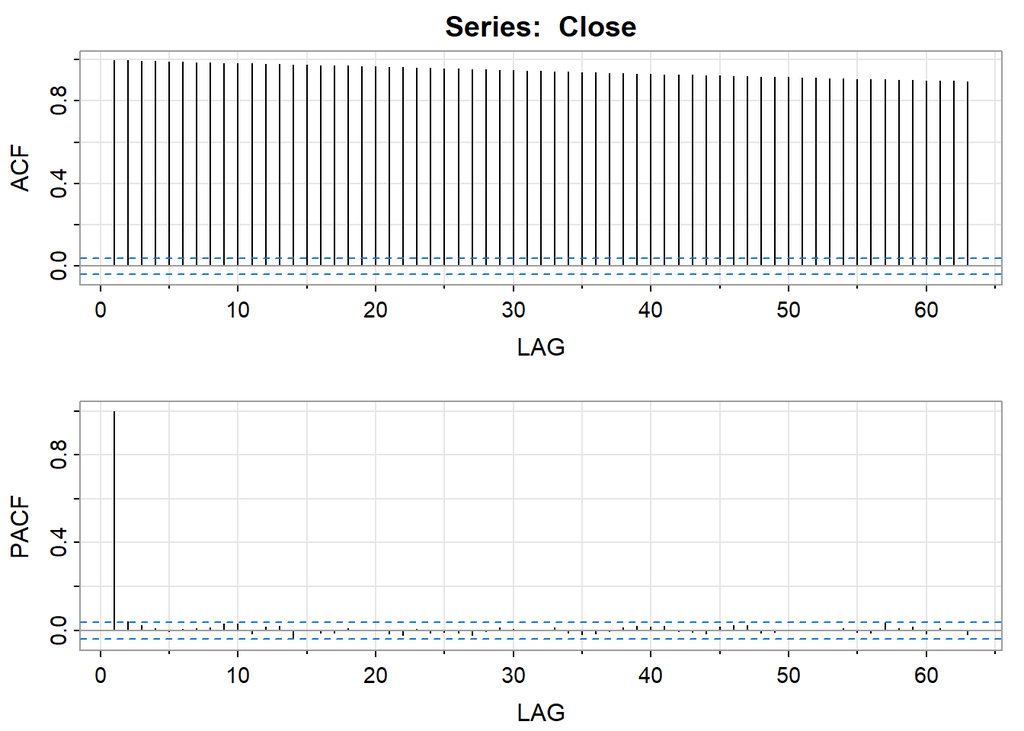

```
##      [,1] [,2] [,3] [,4] [,5] [,6] [,7] [,8] [,9] [,10] [,11] [,12] [,13] [,14]
## ACF     1 1.00 0.99 0.99 0.99 0.99 0.99 0.98 0.98  0.98  0.98  0.98  0.98  0.98
## PACF    1 0.04 0.02 0.01 0.00 0.01 0.01 0.01 0.03  0.03 -0.01  0.02  0.02 -0.04
##      [,15] [,16] [,17] [,18] [,19] [,20] [,21] [,22] [,23] [,24] [,25] [,26]
## ACF   0.97  0.97  0.97  0.97  0.97  0.97  0.96  0.96  0.96  0.96  0.96  0.96
## PACF  0.00 -0.01 -0.01  0.01  0.00  0.00 -0.01 -0.02  0.01 -0.01 -0.01 -0.01
##      [,27] [,28] [,29] [,30] [,31] [,32] [,33] [,34] [,35] [,36] [,37] [,38]
## ACF   0.95  0.95  0.95  0.95  0.95  0.94  0.94  0.94  0.94  0.94  0.94  0.93
## PACF -0.02  0.00  0.01  0.01  0.00  0.00  0.01 -0.01 -0.02 -0.01 -0.01  0.01
##      [,39] [,40] [,41] [,42] [,43] [,44] [,45] [,46] [,47] [,48] [,49] [,50]
## ACF   0.93  0.93  0.93  0.93  0.92  0.92  0.92  0.92  0.92  0.92  0.92  0.91
## PACF  0.02  0.02  0.02 -0.01 -0.01 -0.01  0.02  0.02  0.02 -0.01 -0.01  0.00
##      [,51] [,52] [,53] [,54] [,55] [,56] [,57] [,58] [,59] [,60] [,61] [,62]
## ACF   0.91  0.91  0.91  0.91  0.91  0.90  0.90  0.90  0.90  0.90  0.90   0.9
## PACF  0.00  0.00  0.00  0.01 -0.01 -0.01  0.03  0.01  0.02 -0.01  0.01   0.0
##      [,63]
## ACF   0.89
## PACF -0.02
```

```r
acf2(Close)
```

Pada output diatas terlihat plot ACF dan PACF berdasarkan data Close. Pada plot di atas terlihat bahwa data belum stasioner karena setiap lagnya keluar dari selang interval.

## Melakukan differencing 1 terhadap data

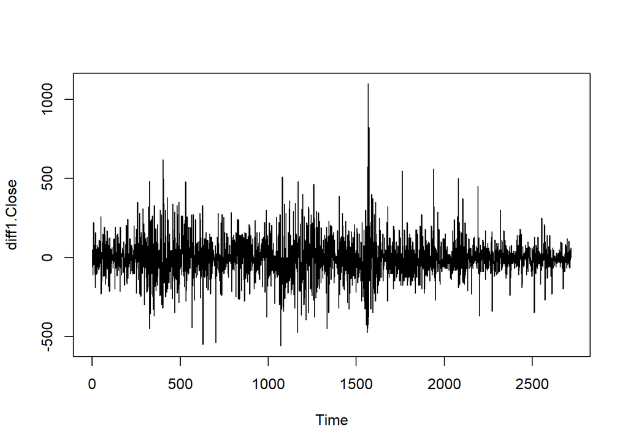

```r
diff1.Close = diff(Close)
plot.ts(diff1.Close)
```

Pada output diatas terlihat plot pada differencing 1 berdasarkan data Close. Pada plot di atas terlihat bahwa data masih belum stasioner karena masih terlihat fluktuatif. Data mengalami lonjakan naik turun yang cukup besar.

## Plot ACF dan PACF differencing 1 kali

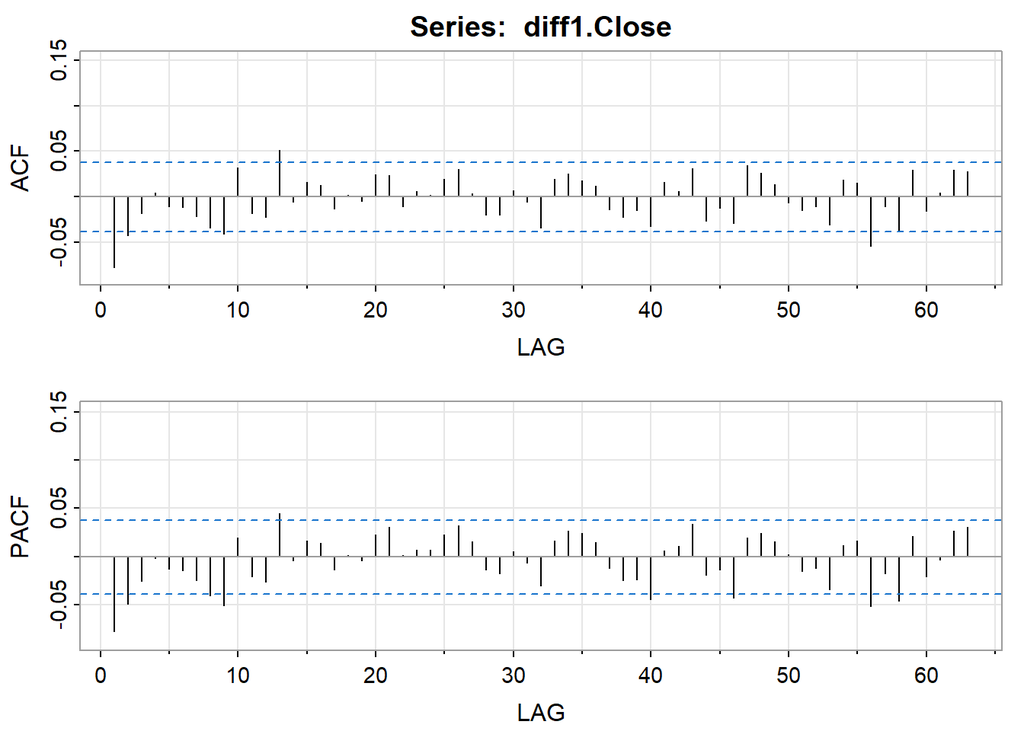

```
##       [,1]  [,2]  [,3] [,4]  [,5]  [,6]  [,7]  [,8]  [,9] [,10] [,11] [,12]
## ACF  -0.08 -0.04 -0.02    0 -0.01 -0.01 -0.02 -0.03 -0.04  0.03 -0.02 -0.02
## PACF -0.08 -0.05 -0.03    0 -0.01 -0.01 -0.02 -0.04 -0.05  0.02 -0.02 -0.03
##      [,13] [,14] [,15] [,16] [,17] [,18] [,19] [,20] [,21] [,22] [,23] [,24]
## ACF   0.05 -0.01  0.02  0.01 -0.01     0 -0.01  0.02  0.02 -0.01  0.01  0.00
## PACF  0.04  0.00  0.02  0.01 -0.01     0  0.00  0.02  0.03  0.00  0.01  0.01
##      [,25] [,26] [,27] [,28] [,29] [,30] [,31] [,32] [,33] [,34] [,35] [,36]
## ACF   0.02  0.03  0.00 -0.02 -0.02  0.01 -0.01 -0.03  0.02  0.03  0.02  0.01
## PACF  0.02  0.03  0.02 -0.01 -0.02  0.01 -0.01 -0.03  0.02  0.03  0.02  0.01
##      [,37] [,38] [,39] [,40] [,41] [,42] [,43] [,44] [,45] [,46] [,47] [,48]
## ACF  -0.01 -0.02 -0.02 -0.03  0.02  0.01  0.03 -0.03 -0.01 -0.03  0.03  0.03
## PACF -0.01 -0.02 -0.02 -0.04  0.01  0.01  0.03 -0.02 -0.01 -0.04  0.02  0.02
##      [,49] [,50] [,51] [,52] [,53] [,54] [,55] [,56] [,57] [,58] [,59] [,60]
## ACF   0.01 -0.01 -0.01 -0.01 -0.03  0.02  0.01 -0.05 -0.01 -0.04  0.03 -0.02
## PACF  0.02  0.00 -0.01 -0.01 -0.03  0.01  0.02 -0.05 -0.02 -0.05  0.02 -0.02
##      [,61] [,62] [,63]
## ACF      0  0.03  0.03
## PACF     0  0.03  0.03
```

```r
acf2(diff1.Close)
```

Pada output diatas terlihat plot ACF dan PACF berdasarkan data differencing 1 kali.

## Melakukan differencing 2 terhadap data

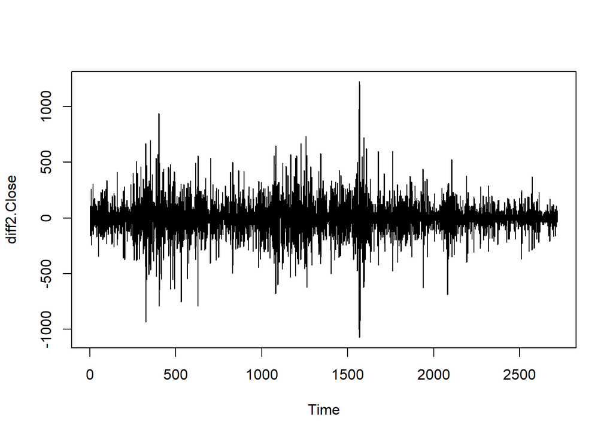

```r
diff2.Close = diff(diff1.Close)
plot(diff2.Close)
```

Pada output diatas terlihat plot pada differencing 2 berdasarkan data differencing 1. Pada plot di atas terlihat bahwa data belum stasioner karena masih terlihat fluktuatif. Data mengalami lonjakan naik turun yang cukup besar.

## Plot ACF dan PACF differencing 2

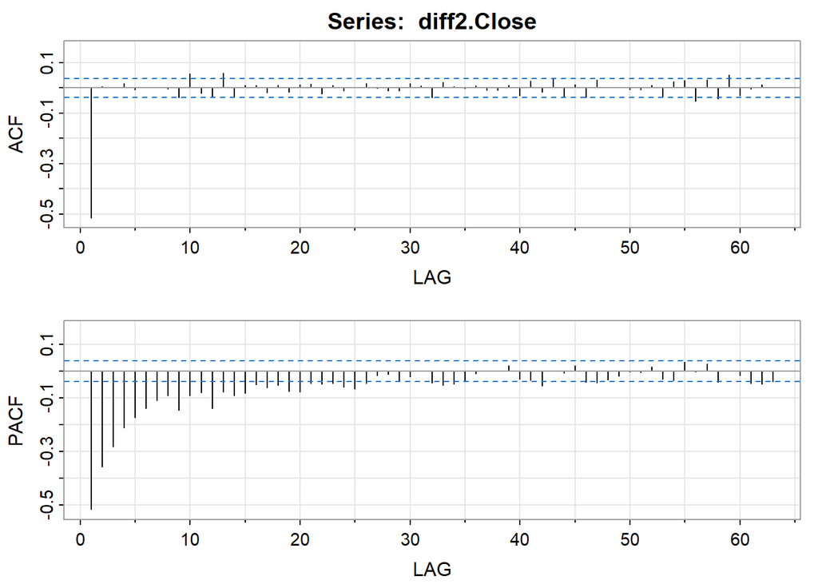

```
##       [,1]  [,2]  [,3]  [,4]  [,5]  [,6]  [,7]  [,8]  [,9] [,10] [,11] [,12]
## ACF  -0.52  0.00  0.00  0.02 -0.01  0.00  0.00  0.00 -0.04  0.06 -0.02 -0.04
## PACF -0.52 -0.36 -0.28 -0.21 -0.17 -0.14 -0.11 -0.09 -0.15 -0.09 -0.08 -0.14
##      [,13] [,14] [,15] [,16] [,17] [,18] [,19] [,20] [,21] [,22] [,23] [,24]
## ACF   0.06 -0.04  0.01  0.01 -0.02  0.01 -0.02  0.01  0.02 -0.02  0.01 -0.01
## PACF -0.08 -0.09 -0.08 -0.05 -0.06 -0.05 -0.07 -0.08 -0.04 -0.05 -0.05 -0.06
##      [,25] [,26] [,27] [,28] [,29] [,30] [,31] [,32] [,33] [,34] [,35] [,36]
## ACF   0.00  0.02  0.00 -0.01 -0.01  0.02  0.01 -0.04  0.02  0.01  0.00  0.01
## PACF -0.07 -0.05 -0.02 -0.01 -0.03 -0.02  0.00 -0.04 -0.05 -0.05 -0.04 -0.01
##      [,37] [,38] [,39] [,40] [,41] [,42] [,43] [,44] [,45] [,46] [,47] [,48]
## ACF  -0.01 -0.01  0.01 -0.03  0.03 -0.02  0.04 -0.03  0.01 -0.04  0.03  0.00
## PACF  0.00  0.00  0.02 -0.03 -0.03 -0.05  0.00 -0.01  0.02 -0.04 -0.04 -0.03
##      [,49] [,50] [,51] [,52] [,53] [,54] [,55] [,56] [,57] [,58] [,59] [,60]
## ACF   0.00 -0.01 -0.01  0.01 -0.03  0.02  0.03 -0.05  0.03 -0.04  0.05 -0.03
## PACF -0.02  0.00  0.00  0.02 -0.03 -0.03  0.03  0.00  0.03 -0.04  0.00 -0.02
##      [,61] [,62] [,63]
## ACF   0.00  0.01  0.00
## PACF -0.04 -0.05 -0.04
```

```r
acf2(diff2.Close)
```

Pada output diatas terlihat plot ACF dan PACF berdasarkan data differencing 2 kali.

## Melihat plot dalam bentuk matriks

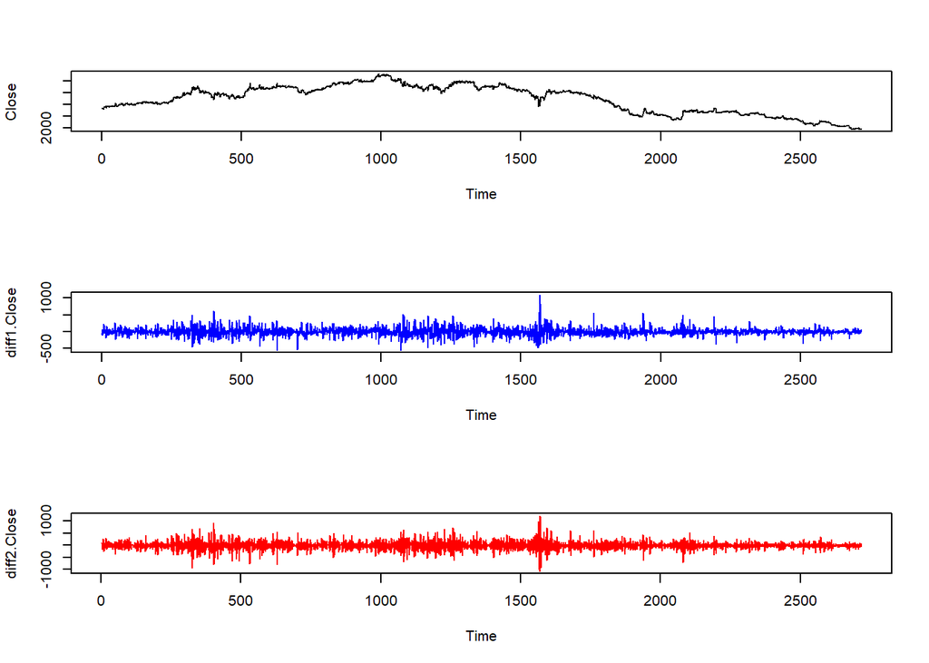

```r
par(mfrow=c(3,1))
plot.ts(Close)
plot.ts(diff1.Close, col = "blue")
plot.ts(diff2.Close, col = "red")
```

Pada output diatas terlihat plot close pada data awal, differencing 1 kali, dan differencing 2 kali. Pada plot differencing 1 itu sudah lurus pada sumbu X namun ada beberapa lonjakan. Pada differencing 2 juga terdapat lonjakan.

## Transformasi

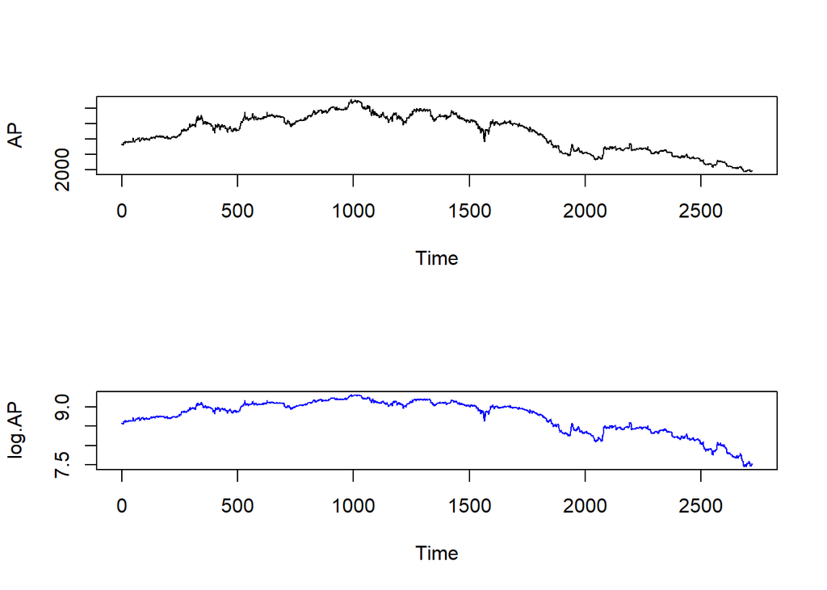

```r
AP=Close
log.AP = log(AP)
par(mfrow = c(2,1))
plot.ts(AP)
plot.ts(log.AP, col = 'blue')
```

Pada output diatas terlihat plot yang sudah di transformasi. Pada plot data tersebut menunjukkan tren naik dan tren turun.

## Melakukan differencing pada log AP

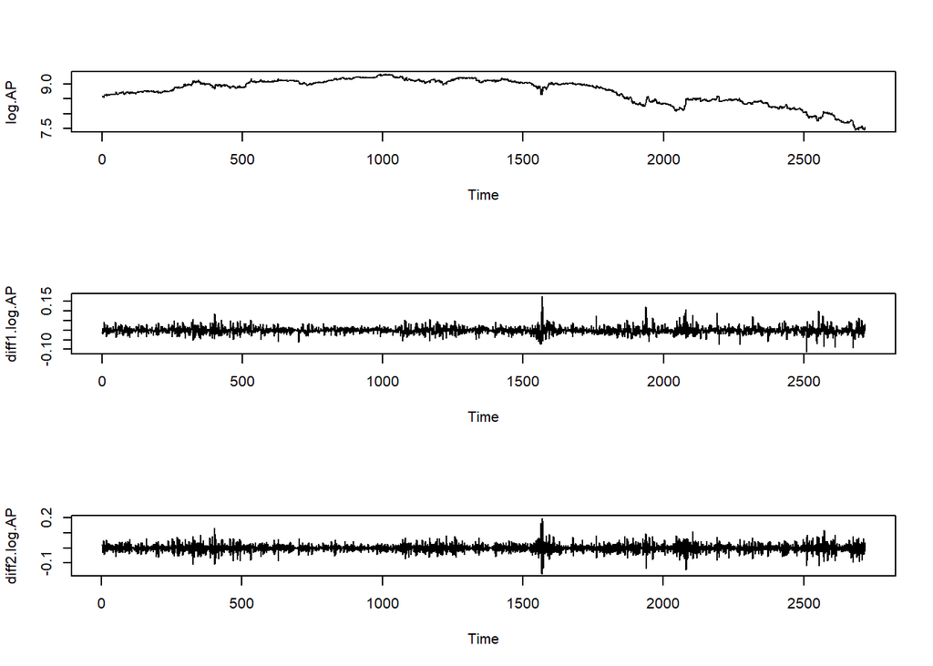

```r
par(mfrow = c(3,1))
plot(log.AP)
diff1.log.AP = diff(log.AP)
plot.ts(diff1.log.AP)
diff2.log.AP = diff(diff1.log.AP)
plot.ts(diff2.log.AP)
```

## Plot ACF dan PACF dengan transformasi logaritma

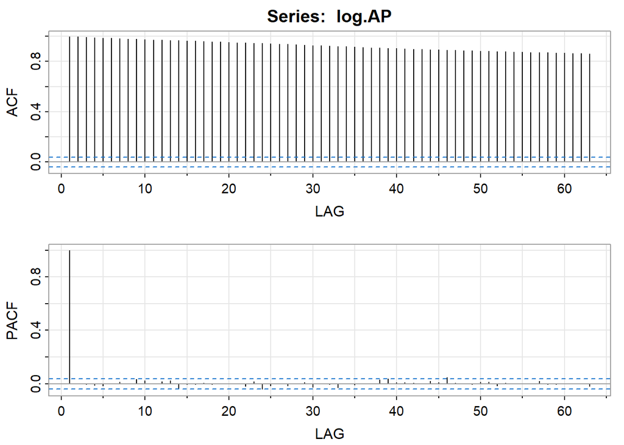

```
##      [,1] [,2] [,3]  [,4]  [,5] [,6] [,7] [,8] [,9] [,10] [,11] [,12] [,13]
## ACF     1 0.99 0.99  0.99  0.99 0.98 0.98 0.98 0.98  0.97  0.97  0.97  0.97
## PACF    1 0.00 0.00 -0.01 -0.02 0.00 0.01 0.00 0.03  0.02  0.00  0.01  0.02
##      [,14] [,15] [,16] [,17] [,18] [,19] [,20] [,21] [,22] [,23] [,24] [,25]
## ACF   0.97  0.96  0.96  0.96  0.96  0.95  0.95  0.95  0.95  0.95  0.94  0.94
## PACF -0.03 -0.01  0.00  0.01  0.00  0.00  0.00  0.00 -0.02  0.02 -0.04 -0.02
##      [,26] [,27] [,28] [,29] [,30] [,31] [,32] [,33] [,34] [,35] [,36] [,37]
## ACF   0.94  0.94  0.93  0.93  0.93  0.93  0.92  0.92  0.92  0.92  0.91  0.91
## PACF  0.00 -0.01  0.00  0.01 -0.03  0.00  0.00 -0.03  0.00 -0.01  0.00  0.00
##      [,38] [,39] [,40] [,41] [,42] [,43] [,44] [,45] [,46] [,47] [,48] [,49]
## ACF   0.91  0.91  0.90  0.90  0.90   0.9  0.89  0.89  0.89  0.89  0.89  0.89
## PACF  0.03  0.04  0.01  0.01  0.01   0.0  0.02  0.01  0.05  0.01  0.00  0.00
##      [,50] [,51] [,52] [,53] [,54] [,55] [,56] [,57] [,58] [,59] [,60] [,61]
## ACF   0.88  0.88  0.88  0.88  0.88  0.87  0.87  0.87  0.87  0.87  0.87  0.86
## PACF  0.01  0.01 -0.02  0.01  0.00  0.00  0.00  0.02  0.00  0.00  0.00  0.00
##      [,62] [,63]
## ACF   0.86  0.86
## PACF  0.00 -0.02
```

```r
acf2(log.AP)
```

Pada output diatas terlihat plot ACF dan PACF berdasarkan data dengan transformasi logaritma. Pada plot di atas terlihat bahwa data belum stasioner karena setiap lagnya keluar dari selang interval.

## Plot ACF dan PACF kombinasi transformasi logartima dengan differencing 1

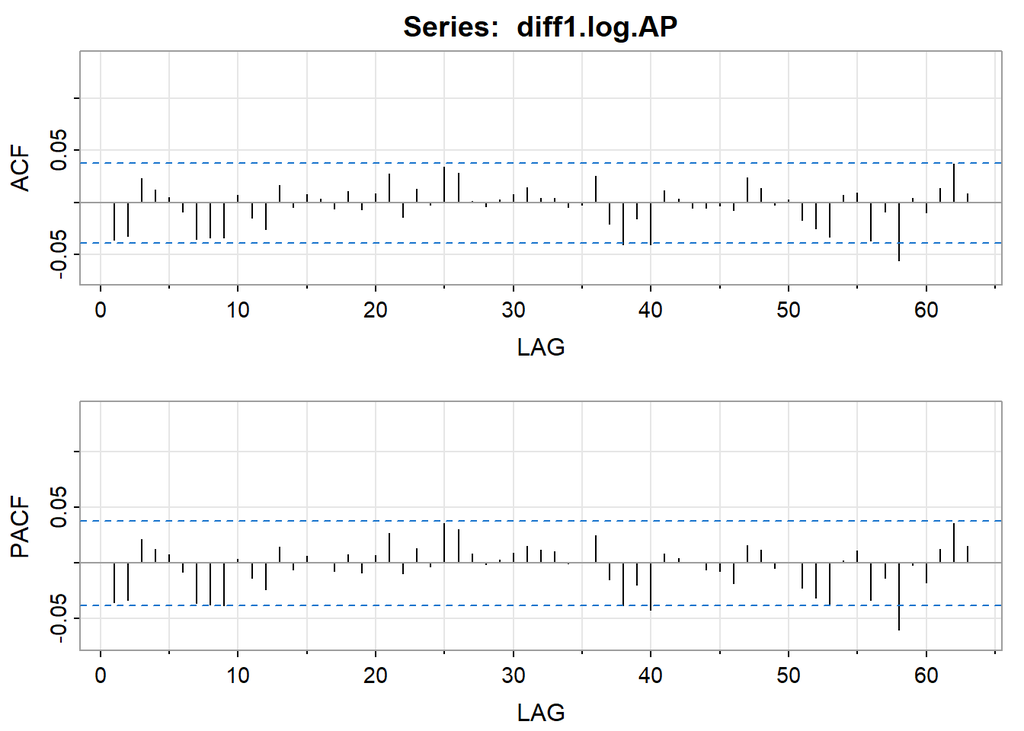

```
##       [,1]  [,2] [,3] [,4] [,5]  [,6]  [,7]  [,8]  [,9] [,10] [,11] [,12] [,13]
## ACF  -0.04 -0.03 0.02 0.01 0.00 -0.01 -0.04 -0.03 -0.03  0.01 -0.01 -0.03  0.02
## PACF -0.04 -0.03 0.02 0.01 0.01 -0.01 -0.04 -0.04 -0.04  0.00 -0.01 -0.02  0.01
##      [,14] [,15] [,16] [,17] [,18] [,19] [,20] [,21] [,22] [,23] [,24] [,25]
## ACF   0.00  0.01     0 -0.01  0.01 -0.01  0.01  0.03 -0.01  0.01     0  0.03
## PACF -0.01  0.01     0 -0.01  0.01 -0.01  0.01  0.03 -0.01  0.01     0  0.04
##      [,26] [,27] [,28] [,29] [,30] [,31] [,32] [,33] [,34] [,35] [,36] [,37]
## ACF   0.03  0.00     0     0  0.01  0.01  0.00  0.00     0     0  0.03 -0.02
## PACF  0.03  0.01     0     0  0.01  0.02  0.01  0.01     0     0  0.02 -0.01
##      [,38] [,39] [,40] [,41] [,42] [,43] [,44] [,45] [,46] [,47] [,48] [,49]
## ACF  -0.04 -0.02 -0.04  0.01     0 -0.01 -0.01  0.00 -0.01  0.02  0.01     0
## PACF -0.04 -0.02 -0.04  0.01     0  0.00 -0.01 -0.01 -0.02  0.02  0.01     0
##      [,50] [,51] [,52] [,53] [,54] [,55] [,56] [,57] [,58] [,59] [,60] [,61]
## ACF      0 -0.02 -0.03 -0.03  0.01  0.01 -0.04 -0.01 -0.06     0 -0.01  0.01
## PACF     0 -0.02 -0.03 -0.04  0.00  0.01 -0.03 -0.01 -0.06     0 -0.02  0.01
##      [,62] [,63]
## ACF   0.04  0.01
## PACF  0.04  0.01
```

```r
acf2(diff1.log.AP)
```

## Plot ACF dan PACF kombinasi transformasi logartima dengan differencing 2

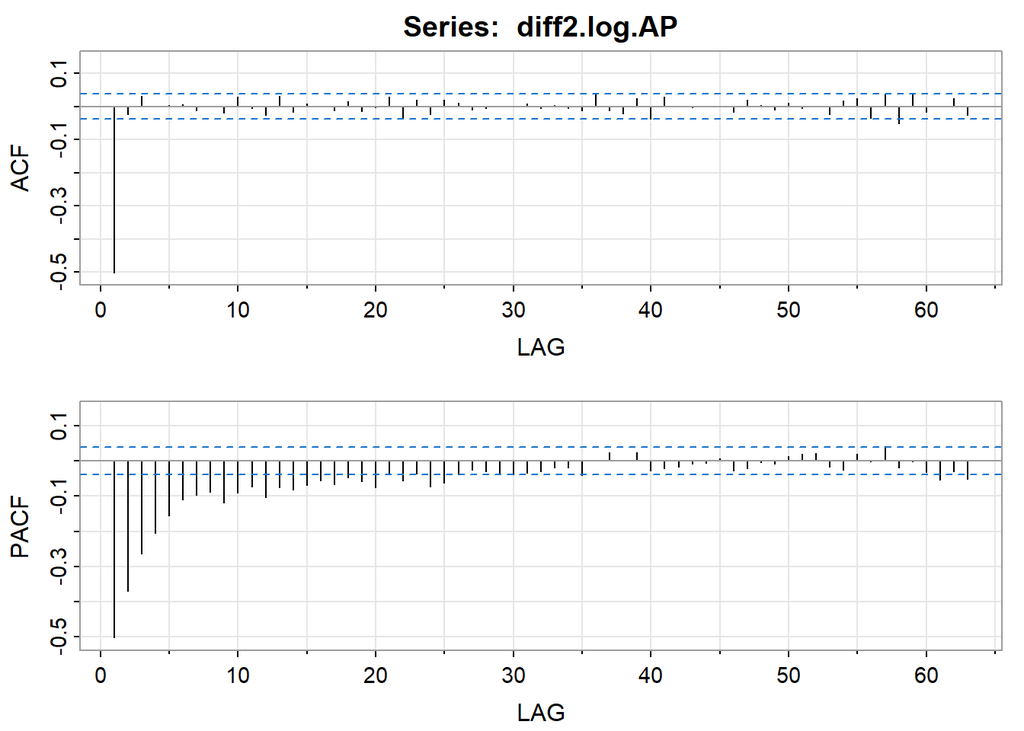

```
##      [,1]  [,2]  [,3] [,4]  [,5]  [,6]  [,7]  [,8]  [,9] [,10] [,11] [,12]
## ACF  -0.5 -0.02  0.03  0.0  0.00  0.01 -0.01  0.00 -0.02  0.03  0.00 -0.03
## PACF -0.5 -0.37 -0.26 -0.2 -0.16 -0.11 -0.10 -0.09 -0.12 -0.09 -0.07 -0.10
##      [,13] [,14] [,15] [,16] [,17] [,18] [,19] [,20] [,21] [,22] [,23] [,24]
## ACF   0.03 -0.02  0.01  0.00 -0.01  0.02 -0.02  0.00  0.03 -0.03  0.02 -0.02
## PACF -0.08 -0.08 -0.07 -0.06 -0.07 -0.05 -0.06 -0.07 -0.03 -0.06 -0.04 -0.07
##      [,25] [,26] [,27] [,28] [,29] [,30] [,31] [,32] [,33] [,34] [,35] [,36]
## ACF   0.02  0.01 -0.01 -0.01  0.00  0.00  0.01  0.00  0.00 -0.01 -0.01  0.04
## PACF -0.06 -0.04 -0.03 -0.03 -0.03 -0.04 -0.03 -0.03 -0.02 -0.02 -0.04  0.00
##      [,37] [,38] [,39] [,40] [,41] [,42] [,43] [,44] [,45] [,46] [,47] [,48]
## ACF  -0.01 -0.02  0.02 -0.04  0.03  0.00  0.00  0.00  0.00 -0.02  0.02     0
## PACF  0.02  0.00  0.02 -0.03 -0.02 -0.02 -0.01 -0.01  0.01 -0.03 -0.02     0
##      [,49] [,50] [,51] [,52] [,53] [,54] [,55] [,56] [,57] [,58] [,59] [,60]
## ACF  -0.01  0.01  0.00  0.00 -0.02  0.02  0.02 -0.04  0.04 -0.05  0.04 -0.02
## PACF -0.01  0.01  0.02  0.02 -0.02 -0.03  0.02  0.00  0.04 -0.02  0.00 -0.03
##      [,61] [,62] [,63]
## ACF   0.00  0.03 -0.03
## PACF -0.05 -0.03 -0.05
```

```r
acf2(diff2.log.AP)
```

## Kesimpulan

Jadi, dapat disimpulkan data kombinasi transformasi logartima dengan differencing 1 sudah stabil. Jadi data yang akan digunakan adalah data kombinasi transformasi logartima dengan differencing 1.

## Cek Stationeritas Terhadap Ragam

```r
bc1 = BoxCox.lambda(diff1.log.AP)
bc1
```

```
## [1] 1
```

Pada output diatas terlihat hasil nilai λ menunjukkan angka 1. Jadi dapat disimpulkan bahwa data tersebut sudah stasioner secara ragam.

## Cek Stasioneritas Terhadap Rata-Rata/Rataan

```r
adf.test(diff1.log.AP)
```

```
##
##  Augmented Dickey-Fuller Test
##
## data:  diff1.log.AP
## Dickey-Fuller = -15.371, Lag order = 13, p-value = 0.01
## alternative hypothesis: stationary
```

# Model Terbaik Menurut R

```r
model1 = auto.arima(diff1.log.AP)
model1
```

```
## Series: diff1.log.AP
## ARIMA(1,1,0) with drift
##
## Coefficients:
##           ar1  drift
##       -0.5019  0e+00
## s.e.   0.0166  3e-04
##
## sigma^2 = 0.0005467:  log likelihood = 6350.21
## AIC=-12694.42   AICc=-12694.41   BIC=-12676.7
```

# EACF

```r
eacf(diff1.Close)
```

```
## AR/MA
##   0 1 2 3 4 5 6 7 8 9 10 11 12 13
## 0 x x o o o o o o x o o  o  x  o
## 1 x o o o o o o o x o o  o  x  o
## 2 x x o o o o o o x o o  o  x  o
## 3 x x x o o o o o o o o  o  x  o
## 4 x x o o o o o o o o o  o  o  o
## 5 x x x o o o o o o o o  o  o  o
## 6 x x x o o x o o o o o  o  o  o
## 7 x x o o o x x o o o o  o  o  o
```

# Kandidat Model

## 1. ARIMA (1,1,0) ##Berdasarkan auto arima

```r
Close.ARIMA.1.1.0 = arima(diff1.log.AP, order = c(1,1,0))
Close.ARIMA.1.1.0
```

```
##
## Call:
## arima(x = diff1.log.AP, order = c(1, 1, 0))
##
## Coefficients:
##           ar1
##       -0.5019
## s.e.   0.0166
##
## sigma^2 estimated as 0.0005463:  log likelihood = 6350.21,  aic = -12698.42
```

## Kandidat Model

## 2. ARIMA (0,1,2)

```r
Close.ARIMA.1.2 = arima(diff1.log.AP, order = c(0,1,2))
Close.ARIMA.1.2
```

```
##
## Call:
## arima(x = diff1.log.AP, order = c(0, 1, 2))
##
## Coefficients:
##           ma1     ma2
##       -1.0340  0.0356
## s.e.   0.0198  0.0198
##
## sigma^2 estimated as 0.0003521:  log likelihood = 6944.07,  aic = -13884.13
```

## Kandidat Model

## 3. ARIMA (0,1,3)

```r
Close.ARIMA.1.3 = arima(diff1.log.AP, order = c(0,1,3))
Close.ARIMA.1.3
```

```
##
## Call:
## arima(x = diff1.log.AP, order = c(0, 1, 3))
##
## Coefficients:
##           ma1     ma2     ma3
##       -1.0349  0.0054  0.0312
## s.e.   0.0192  0.0281  0.0190
##
## sigma^2 estimated as 0.0003518:  log likelihood = 6945.44,  aic = -13884.88
```

## Kandidat Model

## 4. ARIMA (0,1,4)

```r
Close.ARIMA.1.4 = arima(diff1.log.AP, order = c(0,1,4))
Close.ARIMA.1.4
```

```
##
## Call:
## arima(x = diff1.log.AP, order = c(0, 1, 4))
##
## Coefficients:
##           ma1     ma2     ma3      ma4
##       -1.0365  0.0060  0.0566  -0.0244
## s.e.   0.0192  0.0274  0.0277   0.0195
##
## sigma^2 estimated as 0.0003516:  log likelihood = 6946.19,  aic = -13884.38
```

## Kandidat Model

## 5. ARIMA (0,1,5)

```r
Close.ARIMA.1.5 = arima(diff1.log.AP, order = c(0,1,5))
Close.ARIMA.1.5
```

```
##
## Call:
## arima(x = diff1.log.AP, order = c(0, 1, 5))
##
## Coefficients:
##           ma1     ma2     ma3      ma4      ma5
##       -1.0361  0.0053  0.0576  -0.0116  -0.0135
## s.e.   0.0192  0.0276  0.0279   0.0272   0.0200
##
## sigma^2 estimated as 0.0003515:  log likelihood = 6946.4,  aic = -13882.8
```

## Kandidat Model

## 6. ARIMA (0,1,6)

```r
Close.ARIMA.1.6 = arima(diff1.log.AP, order = c(0,1,6))
Close.ARIMA.1.6
```

```
##
## Call:
## arima(x = diff1.log.AP, order = c(0, 1, 6))
##
## Coefficients:
##           ma1     ma2     ma3      ma4      ma5      ma6
##       -1.0360  0.0046  0.0566  -0.0116  -0.0094  -0.0027
## s.e.   0.0192  0.0276  0.0278   0.0272   0.0272   0.0194
##
## sigma^2 estimated as 0.0003515:  log likelihood = 6946.42,  aic = -13880.83
```

## Kandidat Model

## 7. ARIMA (0,1,7)

```r
Close.ARIMA.1.7 = arima(diff1.log.AP, order = c(0,1,7))
Close.ARIMA.1.7
```

```
##
## Call:
## arima(x = diff1.log.AP, order = c(0, 1, 7))
##
## Coefficients:
##           ma1     ma2     ma3      ma4      ma5      ma6     ma7
##       -1.0387  0.0084  0.0561  -0.0102  -0.0105  -0.0185  0.0152
## s.e.   0.0193  0.0277  0.0277   0.0272   0.0273   0.0276  0.0199
##
## sigma^2 estimated as 0.0003514:  log likelihood = 6946.69,  aic = -13879.38
```

## Kandidat Model

## 8. ARIMA (0,1,9)

```r
Close.ARIMA.1.9 = arima(diff1.log.AP, order = c(0,1,9))
Close.ARIMA.1.9
```

```
##
## Call:
## arima(x = diff1.log.AP, order = c(0, 1, 9))
##
## Coefficients:
##           ma1     ma2     ma3      ma4      ma5      ma6      ma7     ma8
##       -1.0407  0.0068  0.0578  -0.0132  -0.0067  -0.0132  -0.0293  0.0035
## s.e.   0.0192  0.0277  0.0278   0.0278   0.0268   0.0278   0.0288  0.0280
##          ma9
##       0.0368
## s.e.  0.0192
##
## sigma^2 estimated as 0.0003503:  log likelihood = 6950.94,  aic = -13883.87
```

## Kandidat Model

## 9. ARIMA (0,1,10)

```r
Close.ARIMA.1.10 = arima(diff1.log.AP, order = c(0,1,10))
Close.ARIMA.1.10
```

```
##
## Call:
## arima(x = diff1.log.AP, order = c(0, 1, 10))
##
## Coefficients:
##           ma1     ma2     ma3      ma4      ma5      ma6      ma7     ma8
##       -1.0395  0.0062  0.0558  -0.0108  -0.0082  -0.0132  -0.0271  0.0031
## s.e.   0.0192  0.0276  0.0277   0.0277   0.0277   0.0276   0.0286  0.0279
##          ma9    ma10
##       0.0009  0.0346
## s.e.  0.0274  0.0189
##
## sigma^2 estimated as 0.0003499:  log likelihood = 6952.61,  aic = -13885.22
```

## Kandidat Model

## 10. ARIMA (0,1,11)

```r
Close.ARIMA.1.11 = arima(diff1.log.AP, order = c(0,1,11))
Close.ARIMA.1.11
```

```
##
## Call:
## arima(x = diff1.log.AP, order = c(0, 1, 11))
##
## Coefficients:
##           ma1     ma2     ma3      ma4      ma5      ma6      ma7     ma8
##       -1.0394  0.0062  0.0556  -0.0106  -0.0082  -0.0133  -0.0270  0.0029
## s.e.   0.0192  0.0276  0.0277   0.0278   0.0277   0.0276   0.0286  0.0279
##          ma9    ma10     ma11
##       0.0009  0.0367  -0.0020
## s.e.  0.0274  0.0275   0.0191
##
## sigma^2 estimated as 0.0003499:  log likelihood = 6952.62,  aic = -13883.23
```

## Kandidat Model

## 11. ARIMA (0,1,13)

```r
Close.ARIMA.1.13 = arima(diff1.log.AP, order = c(0,1,13))
Close.ARIMA.1.13
```

```
##
## Call:
## arima(x = diff1.log.AP, order = c(0, 1, 13))
##
## Coefficients:
##           ma1     ma2     ma3      ma4      ma5      ma6      ma7     ma8
##       -1.0380  0.0056  0.0567  -0.0103  -0.0093  -0.0137  -0.0276  0.0025
## s.e.   0.0192  0.0277  0.0277   0.0277   0.0277   0.0276   0.0282  0.0278
##          ma9    ma10     ma11     ma12    ma13
##       0.0027  0.0367  -0.0183  -0.0094  0.0246
## s.e.  0.0274  0.0274   0.0286   0.0284  0.0192
##
## sigma^2 estimated as 0.0003496:  log likelihood = 6953.79,  aic = -13881.58
```

## Kandidat Model

## 11. ARIMA (1,1,1)

```r
Close.ARIMA.1.1.1 = arima(diff1.log.AP, order = c(1,1,1))
Close.ARIMA.1.1.1
```

```
##
## Call:
## arima(x = diff1.log.AP, order = c(1, 1, 1))
##
## Coefficients:
##           ar1      ma1
##       -0.0383  -0.9984
## s.e.   0.0192   0.0015
##
## sigma^2 estimated as 0.0003521:  log likelihood = 6943.95,  aic = -13883.91
```

## Kandidat Model

## 12. ARIMA (1,1,2)

```r
Close.ARIMA.1.1.2 = arima(diff1.log.AP, order = c(1,1,2))
Close.ARIMA.1.1.2
```

```
##
## Call:
## arima(x = diff1.log.AP, order = c(1, 1, 2))
##
## Coefficients:
```

```
##           ar1      ma1      ma2
##       -0.6843  -0.3193  -0.6781
## s.e.      NaN      NaN      NaN
##
## sigma^2 estimated as 0.0003526:  log likelihood = 6942.11,  aic = -13878.23
```

## Kandidat Model

## 13. ARIMA (1,1,3)

```r
Close.ARIMA.1.1.3 = arima(diff1.log.AP, order = c(1,1,3))
Close.ARIMA.1.1.3
```

```
##
## Call:
## arima(x = diff1.log.AP, order = c(1, 1, 3))
##
## Coefficients:
##           ar1      ma1      ma2     ma3
##       -0.5300  -0.5059  -0.5430  0.0514
## s.e.   0.2185   0.2173   0.2173  0.0189
##
## sigma^2 estimated as 0.0003517:  log likelihood = 6945.72,  aic = -13883.44
```

## Kandidat Model

## 14. ARIMA (1,1,4)

```r
Close.ARIMA.1.1.4 = arima(diff1.log.AP, order = c(1,1,4))
Close.ARIMA.1.1.4
```

```
##
## Call:
## arima(x = diff1.log.AP, order = c(1, 1, 4))
##
## Coefficients:
```

```
##           ar1      ma1      ma2     ma3     ma4
##       -0.7286  -0.3072  -0.7491  0.0419  0.0172
## s.e.      NaN      NaN      NaN  0.0156     NaN
##
## sigma^2 estimated as 0.0003517:  log likelihood = 6945.57,  aic = -13881.14
```

## Kandidat Model

## 15. ARIMA (1,1,5)

```r
Close.ARIMA.1.1.5 = arima(diff1.log.AP, order = c(1,1,5))
Close.ARIMA.1.1.5
```

```
##
## Call:
## arima(x = diff1.log.AP, order = c(1, 1, 5))
##
## Coefficients:
##           ar1      ma1      ma2     ma3     ma4      ma5
##       -0.6544  -0.3822  -0.6726  0.0606  0.0208  -0.0239
## s.e.   0.7784   0.7777   0.8072  0.0251  0.0438   0.0237
##
## sigma^2 estimated as 0.0003515:  log likelihood = 6946.34,  aic = -13880.69
```

## Kandidat Model

## 16. ARIMA (1,1,6)

```r
Close.ARIMA.1.1.6 = arima(diff1.log.AP, order = c(1,1,6))
Close.ARIMA.1.1.6
```

```
##
## Call:
## arima(x = diff1.log.AP, order = c(1, 1, 6))
##
## Coefficients:
```

```
##           ar1      ma1      ma2     ma3     ma4      ma5      ma6
##       -0.7497  -0.2869  -0.7712  0.0612  0.0312  -0.0234  -0.0081
## s.e.      NaN      NaN      NaN  0.0241     NaN   0.0133   0.0151
##
## sigma^2 estimated as 0.0003515:  log likelihood = 6946.42,  aic = -13878.83
```

## Kandidat Model

## 17. ARIMA (1,1,7)

```r
Close.ARIMA.1.1.7 = arima(diff1.log.AP, order = c(1,1,7))
Close.ARIMA.1.1.7
```

```
##
## Call:
## arima(x = diff1.log.AP, order = c(1, 1, 7))
##
## Coefficients:
##           ar1      ma1      ma2     ma3     ma4      ma5      ma6      ma7
##       -0.6915  -0.3446  -0.7104  0.0610  0.0271  -0.0184  -0.0056  -0.0064
## s.e.   0.4989   0.4984   0.5171  0.0249  0.0375   0.0247   0.0218   0.0196
##
## sigma^2 estimated as 0.0003515:  log likelihood = 6946.46,  aic = -13876.93
```

## Kandidat Model

## 18. ARIMA (1,1,9)

```r
Close.ARIMA.1.1.9 = arima(diff1.log.AP, order = c(1,1,9))
Close.ARIMA.1.1.9
```

```
##
## Call:
## arima(x = diff1.log.AP, order = c(1, 1, 9))
##
## Coefficients:
```

```
##           ar1     ma1     ma2     ma3     ma4      ma5      ma6      ma7
##       -0.7383  -0.302  -0.763  0.0636  0.0313  -0.0181  -0.0199  -0.0401
## s.e.      NaN     NaN     NaN  0.0247     NaN   0.0229   0.0254   0.0238
##          ma8     ma9
##       0.0125  0.0385
## s.e.  0.0194  0.0146
##
## sigma^2 estimated as 0.0003508:  log likelihood = 6949.24,  aic = -13878.48
```

## Kandidat Model

## 19. ARIMA (1,1,10)

```r
Close.ARIMA.1.1.10 = arima(diff1.log.AP, order = c(1,1,10))
Close.ARIMA.1.1.10
```

```
##
## Call:
## arima(x = diff1.log.AP, order = c(1, 1, 10))
##
## Coefficients:
##           ar1      ma1      ma2     ma3     ma4      ma5      ma6      ma7
##       -0.6671  -0.3737  -0.6867  0.0600  0.0260  -0.0149  -0.0183  -0.0361
## s.e.   1.7605   1.7529   1.8330  0.0344  0.0948   0.0325   0.0259   0.0407
##           ma8     ma9    ma10
##       -0.0164  0.0190  0.0440
## s.e.   0.0536  0.1215  0.0491
##
## sigma^2 estimated as 0.0003501:  log likelihood = 6951.77,  aic = -13881.54
```

## Kandidat Model

## 20. ARIMA (1,1,11)

```r
Close.ARIMA.1.1.11 = arima(diff1.log.AP, order = c(1,1,11))
Close.ARIMA.1.1.11
```

```
##
## Call:
## arima(x = diff1.log.AP, order = c(1, 1, 11))
##
## Coefficients:
```

```
##           ar1      ma1      ma2     ma3     ma4     ma5      ma6      ma7
##       -0.7446  -0.2952  -0.7683  0.0608  0.0306  -0.017  -0.0188  -0.0362
## s.e.      NaN      NaN      NaN  0.0246     NaN   0.024   0.0249   0.0238
##           ma8     ma9    ma10    ma11
##       -0.0174  0.0030  0.0316  0.0298
## s.e.   0.0199  0.0248  0.0182     NaN
##
## sigma^2 estimated as 0.0003499:  log likelihood = 6952.68,  aic = -13881.36
```

## Kandidat Model

## 21. ARIMA (1,1,13)

```r
Close.ARIMA.1.1.13 = arima(diff1.log.AP, order = c(1,1,13))
Close.ARIMA.1.1.13
```

```
##
## Call:
## arima(x = diff1.log.AP, order = c(1, 1, 13))
##
## Coefficients:
##           ar1      ma1      ma2     ma3     ma4      ma5      ma6      ma7
##       -0.7155  -0.3244  -0.7370  0.0607  0.0297  -0.0160  -0.0204  -0.0356
## s.e.   2.3542   2.3459   2.4467  0.0297  0.1270   0.0298   0.0349   0.0356
##           ma8     ma9    ma10    ma11     ma12    ma13
##       -0.0183  0.0044  0.0392  0.0068  -0.0167  0.0306
## s.e.   0.0645  0.0250  0.0277  0.0844   0.0606  0.0607
##
## sigma^2 estimated as 0.0003495:  log likelihood = 6953.99,  aic = -13879.99
```

## Kandidat Model

## 22. ARIMA (2,1,2)

```r
Close.ARIMA.2.1.2 = arima(diff1.log.AP, order = c(2,1,2))
Close.ARIMA.2.1.2
```

```
##
## Call:
## arima(x = diff1.log.AP, order = c(2, 1, 2))
##
## Coefficients:
```

```
##           ar1      ar2      ma1      ma2
##       -0.9031  -0.0433  -0.1327  -0.8641
## s.e.      NaN   0.0188      NaN      NaN
##
## sigma^2 estimated as 0.000352:  log likelihood = 6944.61,  aic = -13881.21
```

## Kandidat Model

## 23. ARIMA (2,1,3)

```r
Close.ARIMA.2.1.3 = arima(diff1.log.AP, order = c(2,1,3))
Close.ARIMA.2.1.3
```

```
##
## Call:
## arima(x = diff1.log.AP, order = c(2, 1, 3))
##
## Coefficients:
##           ar1      ar2     ma1      ma2      ma3
##       -1.5319  -0.9970  0.5315  -0.5353  -0.9907
## s.e.   0.0038   0.0056  0.0051   0.0059   0.0093
##
## sigma^2 estimated as 0.0003507:  log likelihood = 6949.41,  aic = -13888.83
```

## Kandidat Model

## 24. ARIMA (2,1,4)

```r
Close.ARIMA.2.1.4 = arima(diff1.log.AP, order = c(2,1,4))
Close.ARIMA.2.1.4
```

```
##
## Call:
## arima(x = diff1.log.AP, order = c(2, 1, 4))
##
## Coefficients:
```

```
##           ar1     ar2     ma1      ma2      ma3     ma4
##       -1.4179  -0.627  0.3815  -0.8359  -0.5918  0.0511
## s.e.   0.2195     NaN  0.2196      NaN      NaN  0.0200
##
## sigma^2 estimated as 0.0003516:  log likelihood = 6946.2,  aic = -13880.4
```

## Kandidat Model

## 25. ARIMA (2,1,5)

```r
Close.ARIMA.2.1.5 = arima(diff1.log.AP, order = c(2,1,5))
Close.ARIMA.2.1.5
```

```
##
## Call:
## arima(x = diff1.log.AP, order = c(2, 1, 5))
##
## Coefficients:
```

```
##           ar1      ar2     ma1     ma2      ma3     ma4     ma5
##       -1.4745  -0.9208  0.4412  -0.598  -0.9021  0.0410  0.0233
## s.e.      NaN      NaN     NaN     NaN      NaN  0.0213  0.0183
##
## sigma^2 estimated as 0.0003512:  log likelihood = 6947.54,  aic = -13881.08
```

## Kandidat Model

## 26. ARIMA (2,1,6)

```r
Close.ARIMA.2.1.6 = arima(diff1.log.AP, order = c(2,1,6))
Close.ARIMA.2.1.6
```

```
##
## Call:
## arima(x = diff1.log.AP, order = c(2, 1, 6))
##
## Coefficients:
```

```
##           ar1      ar2      ma1      ma2      ma3     ma4     ma5      ma6
##       -0.4413  -0.1193  -0.5952  -0.3319  -0.0643  0.0136  -0.007  -0.0128
## s.e.      NaN      NaN      NaN      NaN      NaN     NaN     NaN      NaN
##
## sigma^2 estimated as 0.0003515:  log likelihood = 6946.43,  aic = -13876.86
```

## Kandidat Model

## 27. ARIMA (2,1,7)

```r
Close.ARIMA.2.1.7 = arima(diff1.log.AP, order = c(2,1,7))
Close.ARIMA.2.1.7
```

```
##
## Call:
## arima(x = diff1.log.AP, order = c(2, 1, 7))
##
## Coefficients:
##           ar1      ar2     ma1      ma2      ma3     ma4     ma5      ma6
##       -1.5318  -0.9968  0.4986  -0.5834  -0.9718  0.0821  0.0339  -0.0302
## s.e.   0.0039   0.0054  0.0205   0.0222   0.0255  0.0397  0.0231   0.0269
##           ma7
##       -0.0236
## s.e.   0.0221
##
## sigma^2 estimated as 0.0003497:  log likelihood = 6953.22,  aic = -13888.44
```

## Kandidat Model

## 28. ARIMA (2,1,9)

```r
Close.ARIMA.2.1.9 = arima(diff1.log.AP, order = c(2,1,9))
Close.ARIMA.2.1.9
```

```
##
## Call:
## arima(x = diff1.log.AP, order = c(2, 1, 9))
##
## Coefficients:
##           ar1      ar2     ma1      ma2      ma3     ma4     ma5      ma6
##       -1.5329  -0.9984  0.4976  -0.5840  -0.9691  0.0882  0.0256  -0.0542
## s.e.   0.0039   0.0051  0.0168   0.0209   0.0176  0.0020  0.0299   0.0116
##           ma7     ma8     ma9
##       -0.0292  0.0152  0.0155
## s.e.   0.0188  0.0206  0.0163
##
## sigma^2 estimated as 0.0003496:  log likelihood = 6953.56,  aic = -13885.12
```

## Kandidat Model

## 29. ARIMA (2,1,10)

```r
Close.ARIMA.2.1.10 = arima(diff1.log.AP, order = c(2,1,10))
Close.ARIMA.2.1.10
```

```
##
## Call:
## arima(x = diff1.log.AP, order = c(2, 1, 10))
##
## Coefficients:
##           ar1      ar2     ma1      ma2      ma3     ma4     ma5      ma6
##       -1.8636  -0.9949  0.8266  -0.9352  -0.9712  0.0986  0.0330  -0.0394
## s.e.   0.0057   0.0063  0.0193   0.0239   0.0286  0.0313  0.0283   0.0282
##           ma7      ma8     ma9    ma10
##       -0.0699  -0.0331  0.0499  0.0470
## s.e.   0.0255   0.0250  0.0218  0.0175
##
## sigma^2 estimated as 0.0003501:  log likelihood = 6951.77,  aic = -13879.54
```

## Kandidat Model

## 30. ARIMA (2,1,11)

```r
Close.ARIMA.2.1.11 = arima(diff1.log.AP, order = c(2,1,11))
Close.ARIMA.2.1.11
```

```
##
## Call:
## arima(x = diff1.log.AP, order = c(2, 1, 11))
##
## Coefficients:
##           ar1      ar2     ma1      ma2      ma3     ma4     ma5      ma6
##       -1.5331  -0.9986  0.4941  -0.5906  -0.9753  0.0855  0.0310  -0.0388
## s.e.   0.0074   0.0093  0.0216   0.0229   0.0200  0.0232  0.0338   0.0160
##           ma7      ma8     ma9    ma10    ma11
##       -0.0571  -0.0526  0.0055  0.0604  0.0438
## s.e.   0.0261   0.0339  0.0237  0.0212  0.0277
##
## sigma^2 estimated as 0.0003483:  log likelihood = 6958.38,  aic = -13890.77
```

## Kandidat Model

## 31. ARIMA (2,1,13)

```r
Close.ARIMA.2.1.13 = arima(diff1.log.AP, order = c(2,1,13))
Close.ARIMA.2.1.13
```

```
##
## Call:
## arima(x = diff1.log.AP, order = c(2, 1, 13))
##
## Coefficients:
```

```
##           ar1      ar2     ma1      ma2      ma3     ma4     ma5      ma6
##       -1.5333  -0.9988  0.4967  -0.5883  -0.9758  0.0871  0.0331  -0.0445
## s.e.      NaN      NaN  0.0163   0.0172   0.0201  0.0223  0.0143   0.0163
##           ma7      ma8      ma9    ma10    ma11    ma12    ma13
##       -0.0664  -0.0516  -0.0114  0.0475  0.0531  0.0243  0.0022
## s.e.   0.0219   0.0103   0.0166  0.0216  0.0140  0.0174  0.0172
##
## sigma^2 estimated as 0.000348:  log likelihood = 6959.35,  aic = -13888.69
```

## Kandidat Model

## 32. ARIMA (3,1,3)

```r
Close.ARIMA.3.1.3 = arima(diff1.log.AP, order = c(3,1,3))
Close.ARIMA.3.1.3
```

```
##
## Call:
## arima(x = diff1.log.AP, order = c(3, 1, 3))
##
## Coefficients:
##           ar1      ar2     ar3      ma1     ma2      ma3
##       -0.1289  -0.1991  0.0075  -0.9075  0.0697  -0.1600
## s.e.   0.8364   0.3160  0.0395   0.8359  0.9626   0.3219
##
## sigma^2 estimated as 0.0003516:  log likelihood = 6946.14,  aic = -13880.28
```

## Kandidat Model

## 33. ARIMA (3,1,4)

```r
Close.ARIMA.3.1.4 = arima(diff1.log.AP, order = c(3,1,4))
Close.ARIMA.3.1.4
```

```
##
## Call:
## arima(x = diff1.log.AP, order = c(3, 1, 4))
##
## Coefficients:
```

```
##           ar1      ar2     ar3     ma1     ma2      ma3     ma4
##       -0.1228  -0.2479  0.0596  -0.911  0.1252  -0.2657  0.0536
## s.e.      NaN      NaN     NaN     NaN     NaN   0.5679     NaN
##
## sigma^2 estimated as 0.0003516:  log likelihood = 6946.01,  aic = -13878.03
```

## Kandidat Model

## 34. ARIMA (3,1,5)

```r
Close.ARIMA.3.1.5 = arima(diff1.log.AP, order = c(3,1,5))
Close.ARIMA.3.1.5
```

```
##
## Call:
## arima(x = diff1.log.AP, order = c(3, 1, 5))
##
## Coefficients:
```

```
##           ar1      ar2     ar3      ma1     ma2      ma3    ma4      ma5
##       -0.1157  -0.2323  0.0617  -0.9208  0.1191  -0.2506  0.062  -0.0076
## s.e.   0.5845   0.3303     NaN   0.5844  0.9602      NaN    NaN   0.0276
##
## sigma^2 estimated as 0.0003516:  log likelihood = 6946.09,  aic = -13876.18
```

## Kandidat Model

## 35. ARIMA (3,1,6)

```r
Close.ARIMA.3.1.6 = arima(diff1.log.AP, order = c(3,1,6))
Close.ARIMA.3.1.6
```

```
##
## Call:
## arima(x = diff1.log.AP, order = c(3, 1, 6))
##
## Coefficients:
##           ar1      ar2      ar3      ma1     ma2      ma3      ma4     ma5
##       -0.1977  -0.3520  -0.0323  -0.8389  0.1536  -0.2758  -0.0333  0.0152
## s.e.   0.3532   0.8589   0.3946   0.3539  1.2711   1.2556   0.3517  0.0700
##           ma6
##       -0.0182
## s.e.   0.0287
##
## sigma^2 estimated as 0.0003515:  log likelihood = 6946.47,  aic = -13874.94
```

## Kandidat Model

## 36. ARIMA (3,1,7)

```r
Close.ARIMA.3.1.7 = arima(diff1.log.AP, order = c(3,1,7))
Close.ARIMA.3.1.7
```

```
##
## Call:
## arima(x = diff1.log.AP, order = c(3, 1, 7))
##
## Coefficients:
```

```
##           ar1      ar2     ar3      ma1    ma2      ma3     ma4     ma5
##       -0.1692  -0.2866  0.0345  -0.8721  0.121  -0.2751  0.0353  0.0107
## s.e.      NaN      NaN     NaN      NaN    NaN      NaN     NaN  0.0202
##           ma6      ma7
##       -0.0147  -0.0027
## s.e.   0.0239   0.0206
##
## sigma^2 estimated as 0.0003515:  log likelihood = 6946.44,  aic = -13872.88
```

## Kandidat Model

```r
Close.ARIMA.3.1.7 = arima(diff1.log.AP, order = c(3,1,8))
Close.ARIMA.3.1.7
```

```
##
## Call:
## arima(x = diff1.log.AP, order = c(3, 1, 8))
##
## Coefficients:
```

```
##          ar1     ar2     ar3      ma1     ma2      ma3     ma4      ma5
##       0.1135  0.0762  0.1376  -1.1525  0.0462  -0.0024  0.1352  -0.0310
## s.e.     NaN  0.0239     NaN      NaN     NaN   0.4183     NaN   0.0119
##           ma6      ma7     ma8
##       -0.0166  -0.0197  0.0421
## s.e.      NaN      NaN  0.0186
##
## sigma^2 estimated as 0.0003505:  log likelihood = 6950.16,  aic = -13878.33
```

## Kandidat Model

## 38. ARIMA (3,1,9)

```r
Close.ARIMA.3.1.9 = arima(diff1.log.AP, order = c(3,1,9))
Close.ARIMA.3.1.9
```

```
##
## Call:
## arima(x = diff1.log.AP, order = c(3, 1, 9))
##
## Coefficients:
```

```
##          ar1      ar2     ar3      ma1     ma2      ma3     ma4      ma5
##       0.0629  -0.0083  0.2003  -1.1034  0.0814  -0.1527  0.1932  -0.0075
## s.e.  0.1637      NaN  0.0418   0.1620     NaN      NaN  0.1095   0.0227
##           ma6      ma7      ma8     ma9
##       -0.0314  -0.0147  -0.0024  0.0391
## s.e.   0.0298   0.0179      NaN  0.0111
##
## sigma^2 estimated as 0.0003502:  log likelihood = 6951.55,  aic = -13879.11
```

## Kandidat Model

## 39. ARIMA (3,1,10)

```r
Close.ARIMA.3.1.10 = arima(diff1.log.AP, order = c(3,1,10))
Close.ARIMA.3.1.10
```

```
##
## Call:
## arima(x = diff1.log.AP, order = c(3, 1, 10))
##
## Coefficients:
##           ar1      ar2     ar3      ma1      ma2      ma3     ma4      ma5
##       -0.1930  -0.1274  0.2766  -0.8468  -0.0660  -0.3523  0.2890  -0.0054
## s.e.   0.8724   0.6529  0.2268   0.8725   1.5179   0.7493  0.2458   0.0541
##           ma6      ma7      ma8     ma9    ma10
##       -0.0316  -0.0260  -0.0070  0.0013  0.0469
## s.e.   0.0301   0.0285   0.0274  0.0312  0.0344
##
## sigma^2 estimated as 0.0003497:  log likelihood = 6953.36,  aic = -13880.71
```

## Kandidat Model

## 40. ARIMA (3,1,11)

```r
Close.ARIMA.3.1.11 = arima(diff1.log.AP, order = c(3,1,11))
Close.ARIMA.3.1.11
```

```
##
## Call:
## arima(x = diff1.log.AP, order = c(3, 1, 11))
##
## Coefficients:
##           ar1      ar2     ar3      ma1      ma2      ma3     ma4      ma5
##       -0.2054  -0.1773  0.2957  -0.8350  -0.0273  -0.4267  0.3161  -0.0118
## s.e.   0.7894   0.4143  0.1909   0.7894   1.1263   0.4693  0.2001   0.0343
##           ma6      ma7     ma8      ma9    ma10     ma11
##       -0.0224  -0.0392  0.0045  -0.0082  0.0620  -0.0099
## s.e.   0.0345   0.0323  0.0439   0.0275  0.0249   0.0314
##
## sigma^2 estimated as 0.0003497:  log likelihood = 6953.24,  aic = -13878.48
```

## Kandidat Model

## 41. ARIMA (3,1,13)

```r
Close.ARIMA.3.1.13 = arima(diff1.log.AP, order = c(3,1,13))
Close.ARIMA.3.1.13
```

```
##
## Call:
## arima(x = diff1.log.AP, order = c(3, 1, 13))
##
## Coefficients:
```

```
##          ar1      ar2     ar3     ma1     ma2      ma3     ma4     ma5      ma6
##       -0.138  -0.2829  0.0716  -0.902  0.1462  -0.3088  0.0744  0.0043  -0.0217
## s.e.     NaN      NaN  0.3268     NaN     NaN      NaN  0.3523     NaN   0.0325
##           ma7      ma8      ma9    ma10     ma11   ma12    ma13
##       -0.0311  -0.0051  -0.0026  0.0398  -0.0153  9e-04  0.0233
## s.e.   0.0272   0.0269   0.0218  0.0286   0.0138    NaN     NaN
##
## sigma^2 estimated as 0.0003495:  log likelihood = 6953.96,  aic = -13875.91
```

## Kandidat Model

## 42. ARIMA (4,1,2)

```r
Close.ARIMA.4.1.2 = arima(diff1.log.AP, order = c(4,1,2))
Close.ARIMA.4.1.2
```

```
##
## Call:
## arima(x = diff1.log.AP, order = c(4, 1, 2))
##
## Coefficients:
```

```
##          ar1      ar2      ar3     ar4      ma1     ma2
##       -0.917  -0.0681  -0.0105  0.0195  -0.1199  -0.877
## s.e.     NaN   0.0241   0.0245  0.0184      NaN     NaN
##
## sigma^2 estimated as 0.0003516:  log likelihood = 6946.19,  aic = -13880.37
```

## Kandidat Model

## 43. ARIMA (4,1,3)

```r
Close.ARIMA.4.1.3 = arima(diff1.log.AP, order = c(4,1,3))
Close.ARIMA.4.1.3
```

```
##
## Call:
## arima(x = diff1.log.AP, order = c(4, 1, 3))
##
## Coefficients:
```

```
##           ar1     ar2     ar3    ar4      ma1      ma2     ma3
##       -0.5245  0.0609  0.0084  0.023  -0.5139  -0.5979  0.1140
## s.e.   0.1496  0.2286  0.0279  0.019   0.1494      NaN  0.2138
##
## sigma^2 estimated as 0.0003515:  log likelihood = 6946.3,  aic = -13878.59
```

## Kandidat Model

## 44. ARIMA (4,1,4)

```r
Close.ARIMA.4.1.4 = arima(diff1.log.AP, order = c(4,1,4))
Close.ARIMA.4.1.4
```

```
##
## Call:
## arima(x = diff1.log.AP, order = c(4, 1, 4))
##
## Coefficients:
```

```
##           ar1     ar2      ar3     ar4      ma1      ma2     ma3      ma4
##       -0.3559  0.1225  -0.1531  0.0219  -0.6803  -0.4858  0.3372  -0.1688
## s.e.      NaN  0.2964      NaN  0.0222      NaN   0.1270     NaN      NaN
##
## sigma^2 estimated as 0.0003515:  log likelihood = 6946.55,  aic = -13877.09
```

## Kandidat Model

## 45. ARIMA (4,1,5)

```r
Close.ARIMA.4.1.5 = arima(diff1.log.AP, order = c(4,1,5))
Close.ARIMA.4.1.5
```

```
##
## Call:
## arima(x = diff1.log.AP, order = c(4, 1, 5))
##
## Coefficients:
```

```
##           ar1     ar2      ar3      ar4      ma1      ma2     ma3      ma4
##       -0.3015  0.2231  -0.3363  -0.3193  -0.7314  -0.5291  0.6246  -0.0129
## s.e.   0.5142     NaN      NaN      NaN   0.5154   0.5620     NaN      NaN
##           ma5
##       -0.3485
## s.e.      NaN
##
## sigma^2 estimated as 0.0003511:  log likelihood = 6947.89,  aic = -13877.78
```

## Kandidat Model

## 46. ARIMA (4,1,6)

```r
Close.ARIMA.4.1.6 = arima(diff1.log.AP, order = c(4,1,6))
Close.ARIMA.4.1.6
```

```
##
## Call:
## arima(x = diff1.log.AP, order = c(4, 1, 6))
##
## Coefficients:
```

```
##           ar1     ar2     ar3      ar4      ma1      ma2     ma3      ma4
##       -0.2474  0.3019  -0.413  -0.4162  -0.7901  -0.5504  0.7892  -0.0095
## s.e.      NaN     NaN     NaN      NaN      NaN   0.8399     NaN      NaN
##           ma5    ma6
##       -0.4583  0.022
## s.e.      NaN    NaN
##
## sigma^2 estimated as 0.000351:  log likelihood = 6948.3,  aic = -13876.6
```

## Kandidat Model

## 47. ARIMA (4,1,7)

```r
Close.ARIMA.4.1.7 = arima(diff1.log.AP, order = c(4,1,7))
Close.ARIMA.4.1.7
```

```
##
## Call:
## arima(x = diff1.log.AP, order = c(4, 1, 7))
##
## Coefficients:
```

```
##          ar1     ar2     ar3      ar4      ma1      ma2     ma3      ma4
##       -0.217  0.3102  -0.417  -0.4074  -0.8207  -0.5288  0.8022  -0.0218
## s.e.     NaN     NaN     NaN      NaN      NaN      NaN     NaN      NaN
##           ma5     ma6     ma7
##       -0.4525  0.0203  0.0040
## s.e.      NaN  0.0096  0.0102
##
## sigma^2 estimated as 0.000351:  log likelihood = 6948.33,  aic = -13874.67
```

## Kandidat Model

## 48. ARIMA (4,1,8)

```r
Close.ARIMA.4.1.8 = arima(diff1.log.AP, order = c(4,1,8))
Close.ARIMA.4.1.8
```

```
##
## Call:
## arima(x = diff1.log.AP, order = c(4, 1, 8))
##
## Coefficients:
##          ar1     ar2     ar3      ar4      ma1      ma2     ma3     ma4
##       0.1345  0.5305  0.0239  -0.4866  -1.1745  -0.3836  0.5841  0.4912
## s.e.  0.6913  0.3007  0.9623   0.4114   0.6901   0.9645  0.8037  1.4429
##           ma5      ma6     ma7     ma8
##       -0.5404  -0.0135  0.0044  0.0337
## s.e.   0.4533   0.0968  0.0460  0.0398
##
## sigma^2 estimated as 0.0003501:  log likelihood = 6951.7,  aic = -13879.39
```

## Kandidat Model

## 49. ARIMA (4,1,9)

```r
Close.ARIMA.4.1.9 = arima(diff1.log.AP, order = c(4,1,9))
Close.ARIMA.4.1.9
```

```
##
## Call:
## arima(x = diff1.log.AP, order = c(4, 1, 9))
##
## Coefficients:
```

```
##           ar1     ar2     ar3      ar4      ma1      ma2     ma3     ma4
##       -0.1530  0.3053  0.0787  -0.0245  -0.8873  -0.4597  0.2987  0.1018
## s.e.   0.1133     NaN  0.1774   0.1066   0.1106      NaN  0.4286     NaN
##           ma5      ma6      ma7     ma8     ma9
##       -0.0526  -0.0181  -0.0334  0.0213  0.0309
## s.e.   0.0598   0.0317   0.0264  0.0206  0.0176
##
## sigma^2 estimated as 0.0003501:  log likelihood = 6951.78,  aic = -13877.56
```

## Kandidat Model

## 50. ARIMA (4,1,10)

```r
Close.ARIMA.4.1.10 = arima(diff1.log.AP, order = c(4,1,10))
Close.ARIMA.4.1.10
```

```
##
## Call:
## arima(x = diff1.log.AP, order = c(4, 1, 10))
##
## Coefficients:
```

```
##           ar1     ar2     ar3     ar4      ma1      ma2     ma3      ma4
##       -0.3812  0.1355  0.0197  0.1635  -0.6589  -0.5243  0.1796  -0.1341
## s.e.   0.3389  0.7130     NaN  0.6618   0.3380   0.6979  0.4496   0.5684
##          ma5      ma6     ma7      ma8     ma9    ma10
##       0.1504  -0.0185  -0.037  -0.0113  0.0184  0.0376
## s.e.  0.7341   0.0296   0.043   0.0345     NaN  0.0233
##
## sigma^2 estimated as 0.0003499:  log likelihood = 6952.65,  aic = -13877.3
```

## Kandidat Model

## 51. ARIMA (4,1,11)

```r
Close.ARIMA.4.1.11 = arima(diff1.log.AP, order = c(4,1,11))
Close.ARIMA.4.1.11
```

```
##
## Call:
## arima(x = diff1.log.AP, order = c(4, 1, 11))
##
## Coefficients:
```

```
##           ar1     ar2      ar3     ar4      ma1     ma2     ma3      ma4
##       -0.4422  0.1342  -0.0119  0.1867  -0.5978  -0.587  0.2114  -0.1867
## s.e.   0.5749     NaN   0.2877     NaN   0.5746     NaN     NaN      NaN
##          ma5      ma6      ma7      ma8     ma9    ma10    ma11
##       0.1738  -0.0158  -0.0413  -0.0127  0.0173  0.0278  0.0131
## s.e.     NaN   0.0370      NaN   0.0203  0.0247     NaN  0.0254
##
## sigma^2 estimated as 0.0003499:  log likelihood = 6952.71,  aic = -13875.41
```

## Kandidat Model

## 52. ARIMA (4,1,12)

```r
Close.ARIMA.4.1.12 = arima(diff1.log.AP, order = c(4,1,12))
Close.ARIMA.4.1.12
```

```
##
## Call:
## arima(x = diff1.log.AP, order = c(4, 1, 12))
##
## Coefficients:
```

```
##           ar1     ar2     ar3      ar4      ma1      ma2     ma3     ma4
##       -0.4209  0.3957  0.1032  -0.1679  -0.6184  -0.8285  0.3685  0.2874
## s.e.   0.5641  0.9866  0.7718   1.5153   0.5603   0.5829     NaN  2.3095
##           ma5      ma6      ma7     ma8     ma9    ma10    ma11     ma12
##       -0.2126  -0.0205  -0.0154  0.0023  0.0048  0.0220  0.0199  -0.0078
## s.e.   1.6410   0.0377   0.1251  0.0687  0.0352  0.0797  0.0212   0.0230
##
## sigma^2 estimated as 0.0003498:  log likelihood = 6952.79,  aic = -13873.58
```

## Kandidat Model

## 53. ARIMA (4,1,13)

```r
Close.ARIMA.4.1.13 = arima(diff1.log.AP, order = c(4,1,13))
Close.ARIMA.4.1.13
```

```
##
## Call:
## arima(x = diff1.log.AP, order = c(4, 1, 13))
##
## Coefficients:
##           ar1     ar2      ar3     ar4      ma1      ma2     ma3      ma4
##       -0.4204  0.1465  -0.2275  0.0216  -0.6195  -0.5761  0.4390  -0.2460
## s.e.   0.5252  0.4195   0.5153  0.3630   0.5248   0.4408  0.7398   0.4522
##          ma5      ma6      ma7      ma8     ma9    ma10     ma11     ma12
##       0.0032  -0.0041  -0.0348  -0.0099  0.0057  0.0307  -0.0040  -0.0208
## s.e.  0.3926   0.0448   0.0372   0.0300  0.0290  0.0370   0.0317   0.0245
##         ma13
##       0.0394
## s.e.  0.0258
##
## sigma^2 estimated as 0.0003495:  log likelihood = 6954.17,  aic = -13874.35
```

## Kandidat Model

## 54. ARIMA (5,1,3)

```r
Close.ARIMA.5.1.3 = arima(diff1.log.AP, order = c(5,1,3))
Close.ARIMA.5.1.3
```

```
##
## Call:
## arima(x = diff1.log.AP, order = c(5, 1, 3))
##
## Coefficients:
##           ar1      ar2      ar3      ar4     ar5      ma1     ma2      ma3
##       -0.5523  -1.0502  -0.0358  -0.0208  0.0210  -0.4831  0.4855  -0.9982
## s.e.   0.0193   0.0220   0.0299   0.0220  0.0193   0.0030  0.0051   0.0059
##
## sigma^2 estimated as 0.0003503:  log likelihood = 6949.54,  aic = -13883.09
```

## Kandidat Model

## 55. ARIMA (5,1,4)

```r
Close.ARIMA.5.1.4 = arima(diff1.log.AP, order = c(5,1,4))
Close.ARIMA.5.1.4
```

```
##
## Call:
## arima(x = diff1.log.AP, order = c(5, 1, 4))
##
## Coefficients:
##           ar1      ar2     ar3     ar4     ar5      ma1      ma2      ma3
##       -0.7719  -0.6238  0.1379  0.0134  0.0278  -0.2647  -0.1708  -0.7249
## s.e.   0.1365   0.5678  0.3302  0.0328  0.0179   0.1361   0.4436   0.5667
##          ma4
##       0.1639
## s.e.  0.3102
##
## sigma^2 estimated as 0.0003515:  log likelihood = 6946.45,  aic = -13874.9
```

## Kandidat Model

## 56. ARIMA (5,1,5)

```r
Close.ARIMA.5.1.5 = arima(diff1.log.AP, order = c(5,1,5))
Close.ARIMA.5.1.5
```

```
##
## Call:
## arima(x = diff1.log.AP, order = c(5, 1, 5))
##
## Coefficients:
```

```
##           ar1      ar2      ar3      ar4     ar5      ma1      ma2    ma3
##       -0.3806  -0.0132  -0.0437  -0.7709  0.0038  -0.6526  -0.3618  0.072
## s.e.      NaN   0.1324      NaN      NaN     NaN      NaN      NaN    NaN
##          ma4      ma5
##       0.7411  -0.7953
## s.e.  0.0841      NaN
##
## sigma^2 estimated as 0.0003495:  log likelihood = 6954,  aic = -13888
```

## Kandidat Model

## 57. ARIMA (5,1,6)

```r
Close.ARIMA.5.1.6 = arima(diff1.log.AP, order = c(5,1,6))
Close.ARIMA.5.1.6
```

```
##
## Call:
## arima(x = diff1.log.AP, order = c(5, 1, 6))
##
## Coefficients:
##           ar1     ar2     ar3      ar4     ar5      ma1      ma2     ma3
##       -0.3142  0.0493  0.0185  -0.7193  0.0618  -0.7201  -0.3555  0.0772
## s.e.   0.2548  0.1969  0.1994   0.1670  0.2373   0.2599   0.2231  0.0781
##          ma4      ma5     ma6
##       0.7486  -0.8054  0.0582
## s.e.  0.1208   0.2145  0.2390
##
## sigma^2 estimated as 0.0003495:  log likelihood = 6953.84,  aic = -13885.68
```

## Kandidat Model

## 58. ARIMA (5,1,7)

```r
Close.ARIMA.5.1.7 = arima(diff1.log.AP, order = c(5,1,7))
Close.ARIMA.5.1.7
```

```
##
## Call:
## arima(x = diff1.log.AP, order = c(5, 1, 7))
##
## Coefficients:
##           ar1      ar2      ar3      ar4     ar5      ma1      ma2     ma3
##       -0.1731  -0.0041  -0.2142  -0.9360  0.1000  -0.8614  -0.1699  0.2499
## s.e.   0.2689   0.0892   0.0385   0.0743  0.2624   0.2690   0.1988  0.0539
##          ma4      ma5     ma6     ma7
##       0.7251  -1.0638  0.1031  0.0205
## s.e.  0.0482   0.1942  0.2687  0.0214
##
## sigma^2 estimated as 0.0003487:  log likelihood = 6956.8,  aic = -13889.6
```

## Kandidat Model

## 59. ARIMA (5,1,8)

```r
Close.ARIMA.5.1.8 = arima(diff1.log.AP, order = c(5,1,8))
Close.ARIMA.5.1.8
```

```
##
## Call:
## arima(x = diff1.log.AP, order = c(5, 1, 8))
##
## Coefficients:
##           ar1     ar2     ar3      ar4      ar5      ma1      ma2     ma3
##       -0.1879  0.6375  0.5640  -0.5046  -0.1259  -0.8495  -0.8303  0.1571
## s.e.   0.4785  0.2065  0.4066   0.3714   0.3971   0.4775   0.6402  0.2881
##          ma4      ma5      ma6     ma7     ma8
##       1.0892  -0.4490  -0.1874  0.0247  0.0464
## s.e.  0.2104   0.7112   0.4296  0.0306  0.0350
##
## sigma^2 estimated as 0.0003494:  log likelihood = 6954.46,  aic = -13882.93
```

## Kandidat Model

## 60. ARIMA (5,1,9)

```r
Close.ARIMA.5.1.9 = arima(diff1.log.AP, order = c(5,1,9))
Close.ARIMA.5.1.9
```

```
##
## Call:
## arima(x = diff1.log.AP, order = c(5, 1, 9))
##
## Coefficients:
```

```
##           ar1     ar2     ar3      ar4     ar5      ma1      ma2     ma3
##       -0.0186  0.4006  0.2477  -0.4086  -0.132  -1.0216  -0.4144  0.2267
## s.e.      NaN     NaN     NaN   0.2902     NaN      NaN      NaN     NaN
##          ma4      ma5      ma6     ma7     ma8     ma9
##       0.6601  -0.3210  -0.1804  0.0117  0.0312  0.0092
## s.e.     NaN   0.2208      NaN     NaN  0.0120  0.0183
##
## sigma^2 estimated as 0.0003502:  log likelihood = 6951.52,  aic = -13875.04
```

## Kandidat Model

## 61. ARIMA (5,1,10)

```r
Close.ARIMA.5.1.10 = arima(diff1.log.AP, order = c(5,1,10))
Close.ARIMA.5.1.10
```

```
##
## Call:
## arima(x = diff1.log.AP, order = c(5, 1, 10))
##
## Coefficients:
##           ar1      ar2     ar3      ar4     ar5      ma1      ma2      ma3
##       -0.3638  -0.1279  0.3111  -0.1462  0.1014  -0.6757  -0.2440  -0.3866
## s.e.   0.5801   0.9854  0.3527   0.6153  0.6510   0.5782   0.5592   0.7698
##          ma4      ma5     ma6      ma7      ma8     ma9    ma10
##       0.4813  -0.2611  0.0704  -0.0207  -0.0156  0.0005  0.0535
## s.e.  0.8619   0.3059  0.6774   0.0817   0.0573  0.0310  0.0477
##
## sigma^2 estimated as 0.0003496:  log likelihood = 6953.73,  aic = -13877.46
```

## Kandidat Model

## 62. ARIMA (5,1,11)

```r
Close.ARIMA.5.1.11 = arima(diff1.log.AP, order = c(5,1,11))
Close.ARIMA.5.1.11
```

```
##
## Call:
## arima(x = diff1.log.AP, order = c(5, 1, 11))
##
## Coefficients:
##           ar1      ar2     ar3      ar4     ar5      ma1      ma2      ma3
##       -0.4221  -0.1039  0.3155  -0.0988  0.1634  -0.6176  -0.3280  -0.3662
## s.e.   0.5912   0.9062  0.2998   0.6011  0.5162   0.5896   0.4682   0.7369
##          ma4      ma5     ma6      ma7      ma8     ma9   ma10     ma11
##       0.4423  -0.2755  0.1347  -0.0278  -0.0154  0.0009  0.057  -0.0023
## s.e.  0.7842   0.3417  0.5347   0.0645   0.0575  0.0255  0.032   0.0341
##
## sigma^2 estimated as 0.0003495:  log likelihood = 6954.22,  aic = -13876.44
```

## Kandidat Model

## 63. ARIMA (5,1,12)

```r
Close.ARIMA.5.1.12 = arima(diff1.log.AP, order = c(5,1,12))
Close.ARIMA.5.1.12
```

```
##
## Call:
## arima(x = diff1.log.AP, order = c(5, 1, 12))
##
## Coefficients:
##           ar1      ar2     ar3      ar4     ar5      ma1      ma2      ma3
##       -0.4007  -0.1094  0.2991  -0.0707  0.2513  -0.6381  -0.3003  -0.3560
## s.e.   0.8567   0.9749  0.7105   0.6861  0.6544   0.8573   1.3208   0.6704
##          ma4      ma5     ma6      ma7      ma8      ma9    ma10     ma11
##       0.3961  -0.3335  0.2279  -0.0328  -0.0151  -0.0003  0.0580  -0.0067
## s.e.  0.7533   0.9800  0.7179   0.0569   0.0481   0.0419  0.0333   0.0715
##         ma12
##       0.0026
## s.e.  0.0876
##
## sigma^2 estimated as 0.0003494:  log likelihood = 6954.41,  aic = -13874.81
```

## Kandidat Model

## 64. ARIMA (5,1,13)

```r
Close.ARIMA.5.1.13 = arima(diff1.log.AP, order = c(5,1,13))
Close.ARIMA.5.1.13
```

```
##
## Call:
## arima(x = diff1.log.AP, order = c(5, 1, 13))
##
## Coefficients:
##          ar1     ar2     ar3      ar4     ar5      ma1      ma2     ma3     ma4
##       0.0478  0.3860  0.0097  -0.9860  0.0220  -1.0881  -0.3279  0.4406  0.9913
## s.e.  0.0339  0.0064  0.0131   0.0064  0.0341   0.0285   0.0306  0.0285  0.0231
##           ma5     ma6     ma7     ma8     ma9     ma10     ma11     ma12
##       -1.0744  0.0098  0.0273  0.0032  0.0336  -0.0111  -0.0349  -0.0179
## s.e.   0.0436  0.0317  0.0443  0.0374  0.0389   0.0243   0.0348   0.0310
##         ma13
##       0.0509
## s.e.  0.0203
##
## sigma^2 estimated as 0.0003469:  log likelihood = 6962.29,  aic = -13888.59
```

## Kandidat Model

## 65. ARIMA (6,1,3)

```r
Close.ARIMA.6.1.3 = arima(diff1.log.AP, order = c(6,1,3))
Close.ARIMA.6.1.3
```

```
##
## Call:
## arima(x = diff1.log.AP, order = c(6, 1, 3))
##
## Coefficients:
##           ar1      ar2      ar3     ar4     ar5     ar6     ma1      ma2
##       -1.5643  -1.0803  -0.0694  0.0087  0.0458  0.0207  0.5319  -0.5345
## s.e.   0.0198   0.0365   0.0414  0.0414  0.0358  0.0196  0.0052   0.0043
##           ma3
##       -0.9917
## s.e.   0.0079
##
## sigma^2 estimated as 0.0003497:  log likelihood = 6953.24,  aic = -13888.48
```

## Kandidat Model

## 66. ARIMA (6,1,4)

```r
Close.ARIMA.6.1.4 = arima(diff1.log.AP, order = c(6,1,4))
Close.ARIMA.6.1.4
```

```
##
## Call:
## arima(x = diff1.log.AP, order = c(6, 1, 4))
##
## Coefficients:
##           ar1      ar2      ar3      ar4      ar5     ar6     ma1      ma2
##       -1.2632  -1.2504  -0.8074  -0.0435  -0.0073  0.0128  0.2269  -0.0535
## s.e.   0.8090   0.4684   0.8341   0.0647   0.0436  0.0271  0.8084   0.5248
##           ma3      ma4
##       -0.4274  -0.7391
## s.e.   0.4014   0.7857
##
## sigma^2 estimated as 0.0003515:  log likelihood = 6946.3,  aic = -13872.59
```

## Kandidat Model

## 67. ARIMA (6,1,6)

```r
Close.ARIMA.6.1.6 = arima(diff1.log.AP, order = c(6,1,6))
Close.ARIMA.6.1.6
```

```
##
## Call:
## arima(x = diff1.log.AP, order = c(6, 1, 6))
##
## Coefficients:
##           ar1      ar2      ar3      ar4      ar5      ar6      ma1     ma2
##       -0.8166  -1.1830  -1.2973  -0.6759  -0.7238  -0.0128  -0.2198  0.3416
## s.e.   0.5592   0.3932   0.2710   0.5918   0.2640   0.0381   0.5584  0.3696
##          ma3      ma4     ma5      ma6
##       0.1268  -0.6290  0.0771  -0.6877
## s.e.  0.1987   0.3817  0.4874   0.2473
##
## sigma^2 estimated as 0.0003506:  log likelihood = 6949.86,  aic = -13875.72
```

## Kandidat Model

## 68. ARIMA (6,1,7)

```r
Close.ARIMA.6.1.7 = arima(diff1.log.AP, order = c(6,1,7))
Close.ARIMA.6.1.7
```

```
##
## Call:
## arima(x = diff1.log.AP, order = c(6, 1, 7))
##
## Coefficients:
```

```
##           ar1      ar2      ar3      ar4      ar5      ar6      ma1     ma2
##       -0.9428  -1.7171  -1.4581  -1.4224  -0.8238  -0.4614  -0.0918  0.7459
## s.e.      NaN   0.1349   0.0881      NaN   0.1761      NaN      NaN  0.2610
##           ma3      ma4      ma5      ma6      ma7
##       -0.2575  -0.0472  -0.5601  -0.3444  -0.4325
## s.e.   0.3527   0.2554      NaN      NaN      NaN
##
## sigma^2 estimated as 0.0003508:  log likelihood = 6949.21,  aic = -13872.41
```

## Kandidat Model

## 69. ARIMA (6,1,8)

```r
Close.ARIMA.6.1.8 = arima(diff1.log.AP, order = c(6,1,8))
Close.ARIMA.6.1.8
```

```
##
## Call:
## arima(x = diff1.log.AP, order = c(6, 1, 8))
##
## Coefficients:
```

```
##           ar1     ar2     ar3      ar4     ar5     ar6      ma1      ma2
##       -0.3404  0.2367  0.0815  -0.0132  0.1723  0.1814  -0.7089  -0.5789
## s.e.      NaN  0.0375     NaN   0.1025     NaN     NaN      NaN      NaN
##          ma3     ma4      ma5      ma6     ma7     ma8
##       0.2266  0.1061  -0.2125  -0.0354  0.1706  0.0337
## s.e.     NaN     NaN      NaN      NaN     NaN  0.0206
##
## sigma^2 estimated as 0.0003508:  log likelihood = 6949.3,  aic = -13870.6
```

## Kandidat Model

## 70. ARIMA (6,1,9)

```r
Close.ARIMA.6.1.9 = arima(diff1.log.AP, order = c(6,1,9))
Close.ARIMA.6.1.9
```

```
##
## Call:
## arima(x = diff1.log.AP, order = c(6, 1, 9))
##
## Coefficients:
##           ar1      ar2      ar3      ar4      ar5      ar6      ma1     ma2
##       -0.6162  -1.1241  -0.4907  -0.9998  -0.4600  -0.9132  -0.4147  0.4916
## s.e.   0.0099   0.0413   0.0636   0.0643   0.0424   0.0126   0.0191  0.0351
##           ma3     ma4      ma5     ma6      ma7      ma8     ma9
##       -0.6215  0.5265  -0.5196  0.4509  -0.9209  -0.0025  0.0199
## s.e.   0.0194  0.0141   0.0266  0.0246   0.0154   0.0210  0.0200
##
## sigma^2 estimated as 0.0003483:  log likelihood = 6958.1,  aic = -13886.2
```

## Kandidat Model

## 71. ARIMA (6,1,10)

```r
Close.ARIMA.6.1.10 = arima(diff1.log.AP, order = c(6,1,10))
Close.ARIMA.6.1.10
```

```
##
## Call:
## arima(x = diff1.log.AP, order = c(6, 1, 10))
##
## Coefficients:
```

```
##           ar1      ar2     ar3     ar4     ar5     ar6      ma1      ma2
##       -0.5110  -0.1809  0.0874  0.1612  0.1609  0.0730  -0.5289  -0.3433
## s.e.   0.3306   0.4932  0.2860  0.2931  0.2059  0.3887   0.3296   0.4268
##           ma3      ma4     ma5     ma6     ma7      ma8     ma9    ma10
##       -0.2161  -0.0521  0.0019  0.0671  0.0311  -0.0188  0.0049  0.0563
## s.e.   0.5909   0.1582     NaN  0.4909  0.4210   0.0285  0.0215  0.0237
##
## sigma^2 estimated as 0.0003498:  log likelihood = 6952.99,  aic = -13873.97
```

## Kandidat Model

## 72. ARIMA (6,1,11)

```r
Close.ARIMA.6.1.11 = arima(diff1.log.AP, order = c(6,1,11))
Close.ARIMA.6.1.11
```

```
##
## Call:
## arima(x = diff1.log.AP, order = c(6, 1, 11))
##
## Coefficients:
##           ar1      ar2      ar3      ar4      ar5      ar6      ma1     ma2
##       -0.9700  -1.9623  -1.6686  -1.8630  -0.8290  -0.9114  -0.0636  0.9647
## s.e.   0.0289   0.0703   0.1030   0.1178   0.0868   0.0535   0.0340  0.0544
##           ma3     ma4      ma5     ma6      ma7      ma8     ma9     ma10
##       -0.3039  0.1904  -0.9915  0.1225  -0.8833  -0.0008  0.0083  -0.0215
## s.e.   0.0415  0.0404   0.0395  0.0442   0.0514   0.0273  0.0277   0.0204
##          ma11
##       -0.0069
## s.e.   0.0203
##
## sigma^2 estimated as 0.000348:  log likelihood = 6958.05,  aic = -13882.09
```

## Kandidat Model

## 73. ARIMA (6,1,12)

```r
Close.ARIMA.6.1.12 = arima(diff1.log.AP, order = c(6,1,12))
Close.ARIMA.6.1.12
```

```
##
## Call:
## arima(x = diff1.log.AP, order = c(6, 1, 12))
##
## Coefficients:
```

```
##           ar1     ar2      ar3      ar4      ar5      ar6      ma1     ma2
##       -0.7735  -1.807  -1.5658  -1.7985  -0.6904  -0.9003  -0.2605  1.0105
## s.e.   0.4255     NaN   0.1579      NaN   0.1740   0.1547   0.4261  0.2541
##           ma3     ma4      ma5     ma6      ma7     ma8      ma9     ma10
##       -0.2450  0.2212  -1.0885  0.2604  -0.8914  0.0114  -0.0002  -0.0001
## s.e.   0.0807  0.0543   0.0797  0.4416   0.1620  0.0286   0.0309   0.0294
##          ma11    ma12
##       -0.0265  0.0221
## s.e.   0.0241  0.0210
##
## sigma^2 estimated as 0.0003488:  log likelihood = 6956.49,  aic = -13876.98
```

## Kandidat Model

## 74. ARIMA (6,1,13)

```r
Close.ARIMA.6.1.13 = arima(diff1.log.AP, order = c(6,1,13))
Close.ARIMA.6.1.13
```

```
##
## Call:
## arima(x = diff1.log.AP, order = c(6, 1, 13))
##
## Coefficients:
```

```
##           ar1      ar2      ar3      ar4     ar5     ar6      ma1      ma2
##       -0.3445  -0.2465  -0.1692  -0.5303  0.3987  0.0667  -0.6909  -0.1088
## s.e.      NaN   0.1958   0.1054   0.1167  0.0356  0.1509      NaN      NaN
##           ma3     ma4      ma5     ma6     ma7      ma8     ma9    ma10
##       -0.0276  0.3772  -0.9633  0.3441  0.0680  -0.0518  0.0008  0.0189
## s.e.   0.1541  0.0759   0.0510     NaN  0.1651   0.0312  0.0277  0.0245
##          ma11     ma12    ma13
##       -0.0092  -0.0094  0.0552
## s.e.   0.0245   0.0244  0.0211
##
## sigma^2 estimated as 0.0003484:  log likelihood = 6958.14,  aic = -13878.27
```

## Kandidat Model

## 75. ARIMA (7,1,2)

```r
Close.ARIMA.7.1.2 = arima(diff1.log.AP, order = c(7,1,2))
Close.ARIMA.7.1.2
```

```
##
## Call:
## arima(x = diff1.log.AP, order = c(7, 1, 2))
##
## Coefficients:
##          ar1      ar2     ar3      ar4      ar5      ar6      ar7      ma1
##       0.8187  -0.0484  0.0201  -0.0615  -0.0107  -0.0155  -0.0422  -1.8160
## s.e.  0.0244   0.0247  0.0247   0.0248   0.0248   0.0247   0.0199   0.0073
##          ma2
##       0.8170
## s.e.  0.0088
##
## sigma^2 estimated as 0.0003603:  log likelihood = 6912.71,  aic = -13807.42
```

## Kandidat Model

## 76. ARIMA (7,1,3)

```r
Close.ARIMA.7.1.3 = arima(diff1.log.AP, order = c(7,1,3))
Close.ARIMA.7.1.3
```

```
##
## Call:
## arima(x = diff1.log.AP, order = c(7, 1, 3))
##
## Coefficients:
##          ar1      ar2     ar3      ar4     ar5     ar6      ar7      ma1
##       0.7378  -0.6093  0.0258  -0.0207  0.0012  0.0106  -0.0315  -1.7743
## s.e.  0.0932   0.1521  0.0255   0.0278  0.0265  0.0238   0.0229   0.0884
##          ma2      ma3
##       1.3789  -0.6031
## s.e.  0.3166   0.1577
##
## sigma^2 estimated as 0.0003509:  log likelihood = 6948.78,  aic = -13877.56
```

## Kandidat Model

## 77. ARIMA (7,1,4)

```r
Close.ARIMA.7.1.4 = arima(diff1.log.AP, order = c(7,1,4))
Close.ARIMA.7.1.4
```

```
##
## Call:
## arima(x = diff1.log.AP, order = c(7, 1, 4))
##
## Coefficients:
```

```
##          ar1      ar2     ar3      ar4     ar5     ar6      ar7      ma1
##       0.7252  -0.8729  0.1194  -0.0295  0.0159  0.0074  -0.0224  -1.7633
## s.e.     NaN      NaN     NaN   0.0268  0.0269  0.0236   0.0158      NaN
##          ma2      ma3     ma4
##       1.6335  -0.9757  0.1072
## s.e.     NaN      NaN     NaN
##
## sigma^2 estimated as 0.0003509:  log likelihood = 6948.67,  aic = -13875.34
```

## Kandidat Model

## 78. ARIMA (7,1,7)

```r
Close.ARIMA.7.1.7 = arima(diff1.log.AP, order = c(7,1,7))
Close.ARIMA.7.1.7
```

```
##
## Call:
## arima(x = diff1.log.AP, order = c(7, 1, 7))
##
## Coefficients:
##          ar1      ar2      ar3     ar4      ar5     ar6      ar7      ma1
##       0.6198  -0.5409  -0.1167  0.3800  -0.1460  0.2197  -0.0274  -1.6526
## s.e.  0.1357   0.1668   0.1762  0.1934   0.2046  0.0859   0.0207   0.1402
##          ma2      ma3      ma4     ma5      ma6     ma7
##       1.1787  -0.4021  -0.5319  0.5469  -0.3547  0.2168
## s.e.  0.3049   0.3122   0.3555  0.3873   0.3102  0.0928
##
## sigma^2 estimated as 0.0003508:  log likelihood = 6949.04,  aic = -13870.07
```

## Kandidat Model

## 79. ARIMA (7,1,8)

```r
Close.ARIMA.7.1.8 = arima(diff1.log.AP, order = c(7,1,8))
Close.ARIMA.7.1.8
```

```
##
## Call:
## arima(x = diff1.log.AP, order = c(7, 1, 8))
##
## Coefficients:
```

```
##          ar1      ar2      ar3    ar4      ar5     ar6      ar7      ma1
##       0.5742  -0.4269  -0.4861  0.162  -0.5305  0.1998  -0.5977  -1.6010
## s.e.  0.1153      NaN      NaN  0.397      NaN     NaN   0.1445   0.1415
##          ma2     ma3      ma4     ma5      ma6     ma7      ma8
##       1.0177  0.1078  -0.7094  0.7276  -0.7307  0.7673  -0.5758
## s.e.     NaN     NaN   0.4492  0.2958      NaN     NaN   0.1731
##
## sigma^2 estimated as 0.0003497:  log likelihood = 6952.45,  aic = -13874.9
```

## Kandidat Model

## 80. ARIMA (7,1,9)

```r
Close.ARIMA.7.1.9 = arima(diff1.log.AP, order = c(7,1,9))
Close.ARIMA.7.1.9
```

```
##
## Call:
## arima(x = diff1.log.AP, order = c(7, 1, 9))
##
## Coefficients:
```

```
##           ar1     ar2     ar3     ar4     ar5      ar6     ar7      ma1
##       -0.0956  0.2519  0.0833  0.2454  0.1257  -0.5967  0.1178  -0.9440
## s.e.   0.2011  0.1290     NaN  0.1293     NaN   0.1327  0.1598   0.2008
##           ma2    ma3      ma4     ma5     ma6      ma7     ma8     ma9
##       -0.3433  0.236  -0.1703  0.1016  0.7238  -0.7887  0.1303  0.0562
## s.e.   0.3576    NaN   0.0435     NaN     NaN   0.2128  0.1711  0.0222
##
## sigma^2 estimated as 0.0003496:  log likelihood = 6953.91,  aic = -13875.82
```

## Kandidat Model

## 81. ARIMA (7,1,10)

```r
Close.ARIMA.7.1.10 = arima(diff1.log.AP, order = c(7,1,10))
Close.ARIMA.7.1.10
```

```
##
## Call:
## arima(x = diff1.log.AP, order = c(7, 1, 10))
##
## Coefficients:
```

```
##          ar1      ar2      ar3     ar4      ar5     ar6      ar7      ma1
##       0.4318  -0.3294  -0.0311  0.3104  -0.1972  0.5434  -0.5975  -1.4718
## s.e.     NaN      NaN      NaN  0.1027      NaN     NaN      NaN      NaN
##          ma2      ma3      ma4     ma5      ma6    ma7      ma8      ma9
##       0.7858  -0.2549  -0.3801  0.5349  -0.7732  1.151  -0.6321  -0.0070
## s.e.     NaN      NaN      NaN     NaN      NaN    NaN      NaN   0.0311
##         ma10
##       0.0490
## s.e.  0.0192
##
## sigma^2 estimated as 0.0003492:  log likelihood = 6955.31,  aic = -13876.63
```

## Kandidat Model

## 82. ARIMA (7,1,11)

```r
Close.ARIMA.7.1.11 = arima(diff1.log.AP, order = c(7,1,11))
Close.ARIMA.7.1.11
```

```
##
## Call:
## arima(x = diff1.log.AP, order = c(7, 1, 11))
##
## Coefficients:
```

```
##           ar1      ar2     ar3     ar4     ar5     ar6      ar7      ma1
##       -0.5984  -0.1786  0.1277  0.2170  0.1833  0.0078  -0.0649  -0.4372
## s.e.      NaN      NaN  0.2560  0.2885  0.1900  0.2062   0.1899      NaN
##           ma2      ma3      ma4     ma5     ma6     ma7      ma8     ma9
##       -0.4354  -0.2555  -0.0635  0.0368  0.1514  0.0233  -0.0880  0.0029
## s.e.   0.2854   0.4019   0.2563  0.3812  0.3347  0.2721   0.2131  0.0257
##         ma10    ma11
##       0.0519  0.0157
## s.e.  0.0331  0.0120
##
## sigma^2 estimated as 0.0003497:  log likelihood = 6953.4,  aic = -13870.79
```

## Kandidat Model

## 83. ARIMA (7,1,12)

```r
Close.ARIMA.7.1.12 = arima(diff1.log.AP, order = c(7,1,12))
Close.ARIMA.7.1.12
```

```
##
## Call:
## arima(x = diff1.log.AP, order = c(7, 1, 12))
##
## Coefficients:
```

```
##           ar1      ar2     ar3     ar4     ar5     ar6      ar7      ma1
##       -0.5810  -0.2037  0.1033  0.2126  0.2061  0.0525  -0.0358  -0.4586
## s.e.   0.8063   0.8142  0.5197  0.6104  0.3621  0.5209   0.3402   0.8081
##           ma2      ma3     ma4     ma5     ma6     ma7      ma8     ma9    ma10
##       -0.3926  -0.2544  -0.082  0.0103  0.1306  0.0393  -0.0595  0.0038  0.0581
## s.e.      NaN   1.2056     NaN  0.3515  0.7318  0.6398   0.3238  0.0489  0.0403
##         ma11     ma12
##       0.0101  -0.0028
## s.e.  0.0469   0.0387
##
## sigma^2 estimated as 0.0003497:  log likelihood = 6953.27,  aic = -13868.53
```

## Kandidat Model

## 84. ARIMA (7,1,13)

```r
Close.ARIMA.7.1.13 = arima(diff1.log.AP, order = c(7,1,13))
Close.ARIMA.7.1.13
```

```
##
## Call:
## arima(x = diff1.log.AP, order = c(7, 1, 13))
##
## Coefficients:
```

```
##          ar1      ar2      ar3     ar4      ar5     ar6      ar7      ma1
##       0.3061  -0.5269  -0.1661  0.1766  -0.3773  0.5595  -0.4685  -1.3467
## s.e.  0.2385   0.1834   0.0709  0.1181   0.2476  0.0882   0.1530   0.2391
##          ma2      ma3      ma4     ma5      ma6     ma7      ma8      ma9
##       0.8536  -0.3272  -0.3765  0.5895  -0.9684  1.0310  -0.4935  -0.0130
## s.e.  0.3592   0.1804      NaN  0.3532   0.3383  0.0698   0.1607   0.0377
##         ma10     ma11    ma12    ma13
##       0.0333  -0.0036  0.0038  0.0203
## s.e.  0.0409   0.0359  0.0330  0.0247
##
## sigma^2 estimated as 0.0003491:  log likelihood = 6955.52,  aic = -13871.03
```

# Interpretasi Output Kandidat Model ARIMA

Akaike Information Criterion (AIC) digunakan untuk membandingkan seberapa baik beberapa model statistik. Semakin rendah nilai AIC, semakin baik modelnya.

# List semua model ARIMA yang sudah dibuat

```r
models <- list(
  ARIMA_1_1_0 = Close.ARIMA.1.1.0,
  ARIMA_0_1_2 = Close.ARIMA.1.2,
  ARIMA_0_1_3 = Close.ARIMA.1.3,
  ARIMA_0_1_4 = Close.ARIMA.1.4,
  ARIMA_0_1_5 = Close.ARIMA.1.5,
  ARIMA_0_1_6 = Close.ARIMA.1.6,
  ARIMA_0_1_7 = Close.ARIMA.1.7,
  ARIMA_0_1_9 = Close.ARIMA.1.9,
  ARIMA_0_1_10 = Close.ARIMA.1.10,
  ARIMA_0_1_11 = Close.ARIMA.1.11,
  ARIMA_0_1_13 = Close.ARIMA.1.13,

  ARIMA_1_1_1 = Close.ARIMA.1.1.1,
  ARIMA_1_1_2 = Close.ARIMA.1.1.2,
  ARIMA_1_1_3 = Close.ARIMA.1.1.3,
  ARIMA_1_1_4 = Close.ARIMA.1.1.4,
  ARIMA_1_1_5 = Close.ARIMA.1.1.5,
  ARIMA_1_1_6 = Close.ARIMA.1.1.6,
  ARIMA_1_1_7 = Close.ARIMA.1.1.7,
  ARIMA_1_1_9 = Close.ARIMA.1.1.9,
  ARIMA_1_1_10 = Close.ARIMA.1.1.10,
  ARIMA_1_1_11 = Close.ARIMA.1.1.11,
  ARIMA_1_1_13 = Close.ARIMA.1.1.13,

  ARIMA_2_1_2 = Close.ARIMA.2.1.2,
  ARIMA_2_1_3 = Close.ARIMA.2.1.3,
  ARIMA_2_1_4 = Close.ARIMA.2.1.4,
  ARIMA_2_1_5 = Close.ARIMA.2.1.5,
  ARIMA_2_1_6 = Close.ARIMA.2.1.6,
  ARIMA_2_1_7 = Close.ARIMA.2.1.7,
  ARIMA_2_1_9 = Close.ARIMA.2.1.9,
  ARIMA_2_1_10 = Close.ARIMA.2.1.10,
  ARIMA_2_1_11 = Close.ARIMA.2.1.11,
  ARIMA_2_1_13 = Close.ARIMA.2.1.13,

  ARIMA_3_1_3 = Close.ARIMA.3.1.3,
  ARIMA_3_1_4 = Close.ARIMA.3.1.4,
  ARIMA_3_1_5 = Close.ARIMA.3.1.5,
  ARIMA_3_1_6 = Close.ARIMA.3.1.6,
  ARIMA_3_1_7 = Close.ARIMA.3.1.7,
  ARIMA_3_1_9 = Close.ARIMA.3.1.9,
  ARIMA_3_1_10 = Close.ARIMA.3.1.10,
  ARIMA_3_1_11 = Close.ARIMA.3.1.11,
  ARIMA_3_1_13 = Close.ARIMA.3.1.13,

  ARIMA_4_1_2 = Close.ARIMA.4.1.2,
  ARIMA_4_1_3 = Close.ARIMA.4.1.3,
  ARIMA_4_1_4 = Close.ARIMA.4.1.4,
  ARIMA_4_1_5 = Close.ARIMA.4.1.5,
  ARIMA_4_1_6 = Close.ARIMA.4.1.6,
  ARIMA_4_1_7 = Close.ARIMA.4.1.7,
  ARIMA_4_1_8 = Close.ARIMA.4.1.8,
  ARIMA_4_1_9 = Close.ARIMA.4.1.9,
  ARIMA_4_1_10 = Close.ARIMA.4.1.10,
  ARIMA_4_1_11 = Close.ARIMA.4.1.11,
  ARIMA_4_1_13 = Close.ARIMA.4.1.13,

  ARIMA_5_1_3 = Close.ARIMA.5.1.3,
  ARIMA_5_1_4 = Close.ARIMA.5.1.4,
  ARIMA_5_1_5 = Close.ARIMA.5.1.5,
  ARIMA_5_1_6 = Close.ARIMA.5.1.6,
  ARIMA_5_1_7 = Close.ARIMA.5.1.7,
  ARIMA_5_1_8 = Close.ARIMA.5.1.8,
  ARIMA_5_1_9 = Close.ARIMA.5.1.9,
  ARIMA_5_1_10 = Close.ARIMA.5.1.10,
  ARIMA_5_1_11 = Close.ARIMA.5.1.11,
  ARIMA_5_1_13 = Close.ARIMA.5.1.13,

  ARIMA_6_1_3 = Close.ARIMA.6.1.3,
  ARIMA_6_1_4 = Close.ARIMA.6.1.4,
  ARIMA_6_1_6 = Close.ARIMA.6.1.6,
  ARIMA_6_1_7 = Close.ARIMA.6.1.7,
  ARIMA_6_1_8 = Close.ARIMA.6.1.8,
  ARIMA_6_1_9 = Close.ARIMA.6.1.9,
  ARIMA_6_1_10 = Close.ARIMA.6.1.10,
  ARIMA_6_1_11 = Close.ARIMA.6.1.11,
  ARIMA_6_1_13 = Close.ARIMA.6.1.13,

  ARIMA_7_1_2 = Close.ARIMA.7.1.2,
  ARIMA_7_1_3 = Close.ARIMA.7.1.3,
  ARIMA_7_1_4 = Close.ARIMA.7.1.4,
  ARIMA_7_1_7 = Close.ARIMA.7.1.7,
  ARIMA_7_1_8 = Close.ARIMA.7.1.8,
  ARIMA_7_1_9 = Close.ARIMA.7.1.9,
  ARIMA_7_1_10 = Close.ARIMA.7.1.10,
  ARIMA_7_1_11 = Close.ARIMA.7.1.11,
  ARIMA_7_1_13 = Close.ARIMA.7.1.13
)

# Buat dataframe untuk menyimpan nilai AIC
aic_values <- data.frame(
  Model = names(models),
  AIC = sapply(models, function(model) AIC(model))
)
```

# Mengurutkan Nilai AIC Terendah

```r
# Urutkan dataframe berdasarkan nilai AIC
aic_values <- aic_values[order(aic_values$AIC), ]

# Ambil 5 model dengan nilai AIC terkecil
top_5_models <- head(aic_values, 5)

# Tampilkan hasil dalam format tabel
cat("\n5 Model dengan AIC terkecil:\n")
```

```
##
## 5 Model dengan AIC terkecil:
```

```r
cat(sprintf("%-15s %-10s\n", "Model", "AIC"))
```

```
## Model           AIC
```

```r
cat(sprintf("%-15s %-10.2f\n", top_5_models$Model, top_5_models$AIC))
```

```
## ARIMA_2_1_11    -13888.77
##  ARIMA_5_1_7     -13887.60
##  ARIMA_2_1_3     -13886.83
##  ARIMA_2_1_13    -13886.69
##  ARIMA_5_1_13    -13886.59
```

Berdasarkan kriteria AIC, - **Model ARIMA (2,1,11)** -13888.77 - **Model ARIMA (5,1,7)** -13887.60 - **Model ARIMA (2,1,3)** -13886.83 - **Model ARIMA (2,1,13)** -13886.69 - **Nodel ARIMA (5,1,13)** -13886.59

# Uji Diagnostik Model ARIMA Yang Sudah Didapatkan

# ARIMA (2,1,11)

## Plot Residual

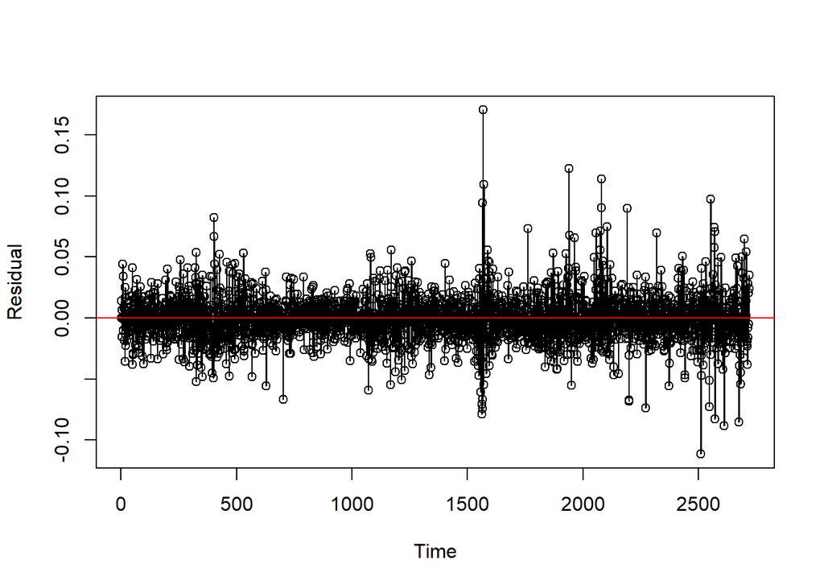

```r
Close.UNVRJK = arima(diff1.log.AP, order = c(2,1,11))
Res.Close = residuals(Close.UNVRJK)
plot(Res.Close, ylab = "Residual", type = "o")
abline(h=0, col = "red")
```

Pada output di atas terlihat plot residual yang mempermudah kita untuk melihat residual yang tidak wajar. Berdasarkan plot di atas terlihat bahwa tidak terdapat tren pada residual.

## Plot Kuantil Kenormalan

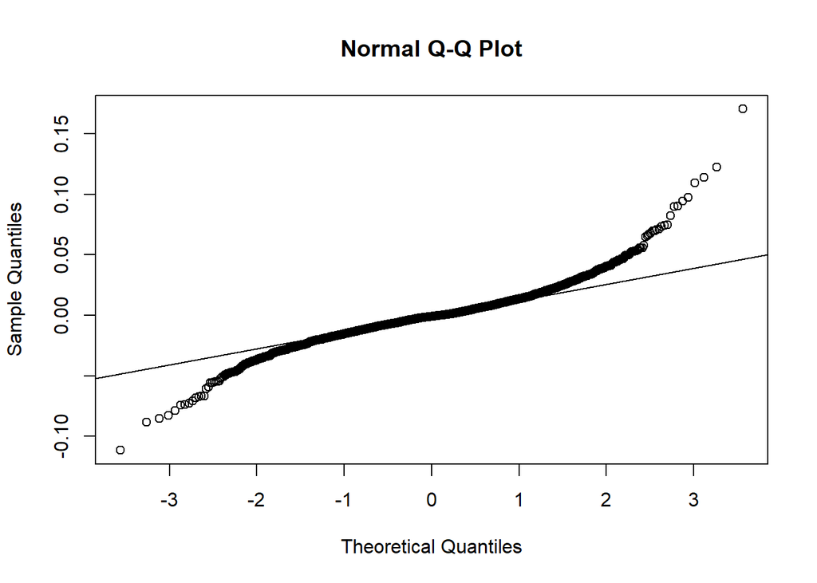

```r
qqnorm(Res.Close)
qqline(Res.Close)
```

Berdasarkan plot kuantil kenormalan terlihat bahwa beberapa titik berada di luar garis kuantil-kuantil.

## Uji Kolmogorov-Smirnov Test

```r
ks.test(Res.Close, "pnorm", mean=mean(Res.Close), sd=sd(Res.Close))
```

```
##
##  Asymptotic one-sample Kolmogorov-Smirnov test
##
## data:  Res.Close
## D = 0.076868, p-value = 2.243e-14
## alternative hypothesis: two-sided
```

Karena nilai p-value (2.243e-14) < α=5%, maka H0 ditolak. Artinya, dapat disimpulkan bahwa residual tidak mengikuti distribusi normal. Sehingga, asumsi normalitas tidak terpenuhi.

```r
kurtosis(Res.Close)
```

```
## [1] 10.12833
```

Nilai kurtosis residual (Res.Close) yang kamu dapatkan adalah 10.12833, yang jauh lebih besar dari 3. Ini berarti distribusi residualnya leptokurtic (lebih runcing dari distribusi normal), yang menunjukkan bahwa data memiliki lebih banyak outlier dibanding distribusi normal.

# Plot Agregasi

## Boxplot untuk melihat outlier

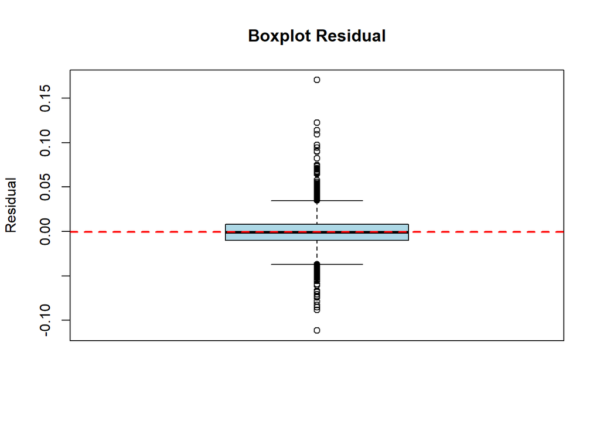

```r
boxplot(Res.Close, main = "Boxplot Residual", ylab = "Residual", col = "lightblue", border = "black")
abline(h = mean(Res.Close), col = "red", lwd = 2, lty = 2)  # Garis putus-putus merah di mean
```

```r
skewness(Res.Close)  # Jika jauh dari 0, kemungkinan butuh sstd
```

```
## [1] 0.6879941
```

## ACF Residual

Untuk memerika asumsi kebebasan derau (noise), kita bisa memeriksa fungsi autokorelasi sampel residual.

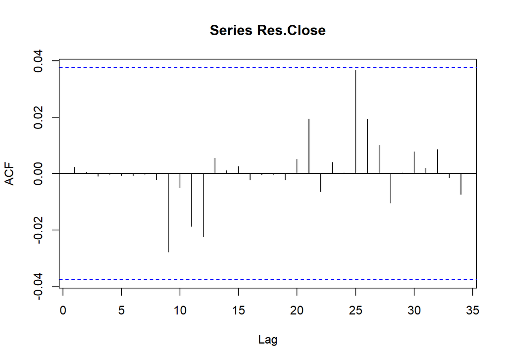

```r
acf(Res.Close)
```

Berdasarkan plot fungsi autokorelasi sampel terlihat bahwa tidak ada yang melewati batas garis putus-putus.

## Menghitung nilai Ljung-Box

```r
ljung_box <- Box.test(Res.Close, lag = 25, type = "Ljung-Box")
ljung_box
```

```
##
##  Box-Ljung test
##
## data:  Res.Close
## X-squared = 9.6388, df = 25, p-value = 0.9975
```

Berdasarkan analisis Box-Ljung test, dimana nilai P-value (0.9975) lebih besar dari α=5%. Jadi dapat disimpulkan bahwa residual tidak berautokorelasi. Sehingga, asumsi non-autokorelasi terpenuhi.

## LJung-Box Statistik

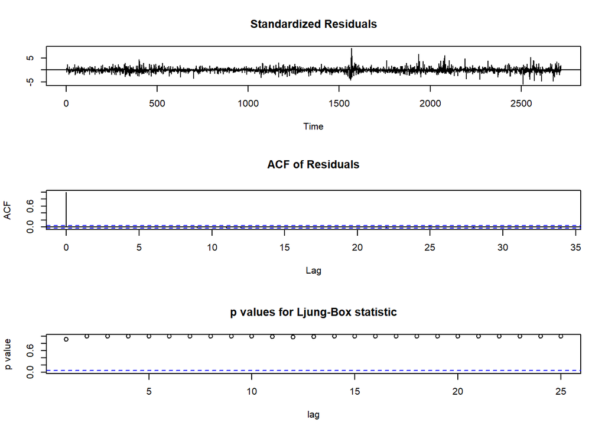

```r
tsdiag(Close.UNVRJK, gof.lag =25)
```

Berdasarkan plot Ljung-Box terlihat bahwa tidak ada p-value yang berada di bawah garis putus-putus (nilai 0.05).

## Uji LM

```r
# Uji ARCH-LM pada standardized residuals
ArchTest(Res.Close, lags = 10)
```

```
##
##  ARCH LM-test; Null hypothesis: no ARCH effects
##
## data:  Res.Close
## Chi-squared = 254.12, df = 10, p-value < 2.2e-16
```

Pengecekan efek arch dilakukan dengan arch.test terhadap Close dan didapatkan nilai p-value 2.2e-16 yang berarti < alpha (0,05). Hal tersebut berarti menolak Ho (tidak ada efek arch) yang menandakan terdapat ada efek arch pada ARIMA (2,1,11)

# ARIMA (5,1,7)

## Plot Residual

```r
Close.UNVRJK517 = arima(diff1.log.AP, order = c(5,1,7))
```

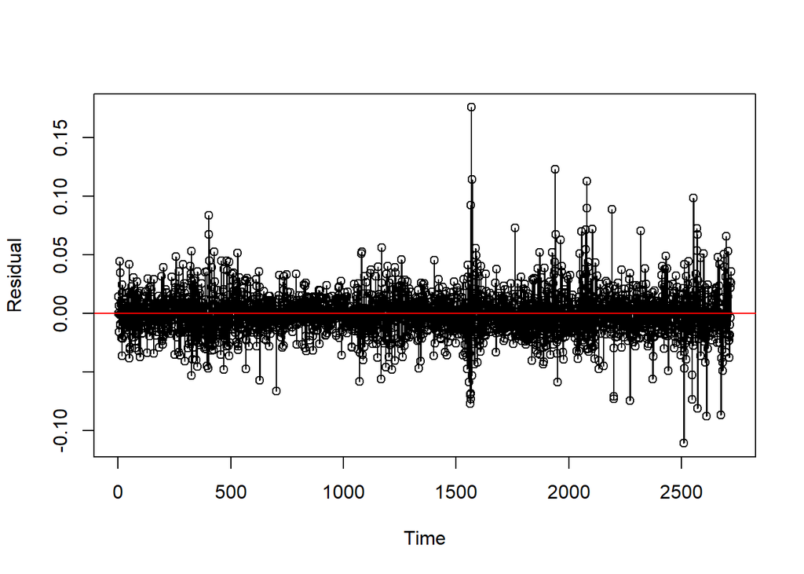

```r
Res.Close517 = residuals(Close.UNVRJK517)
plot(Res.Close517, ylab = "Residual", type = "o")
abline(h=0, col = "red")
```

Pada output di atas terlihat plot residual yang mempermudah kita untuk melihat residual yang tidak wajar. Berdasarkan plot di atas terlihat bahwa tidak terdapat tren pada residual.

## Plot Kuantil Kenormalan

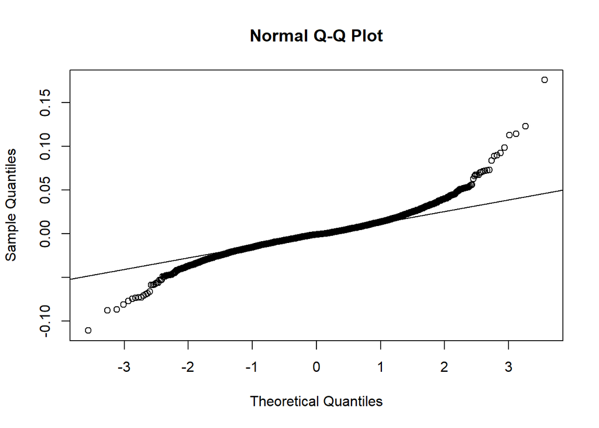

```r
qqnorm(Res.Close517)
qqline(Res.Close517)
```

Berdasarkan plot kuantil kenormalan terlihat bahwa beberapa titik berada di luar garis kuantil-kuantil.

## Uji Kolmogorov-Smirnov Test

```r
ks.test(Res.Close517, "pnorm", mean=mean(Res.Close517), sd=sd(Res.Close517))
```

```
##
##  Asymptotic one-sample Kolmogorov-Smirnov test
##
## data:  Res.Close517
## D = 0.077023, p-value = 1.976e-14
## alternative hypothesis: two-sided
```

Karena nilai p-value (1.976e-14) < α=5%, maka H0 ditolak. Artinya, dapat disimpulkan bahwa residual tidak mengikuti distribusi normal. Sehingga, asumsi normalitas tidak terpenuhi.

```r
kurtosis(Res.Close517)
```

```
## [1] 10.49032
```

Nilai kurtosis residual (Res.Close) yang kamu dapatkan adalah 10.49032, yang jauh lebih besar dari 3. Ini berarti distribusi residualnya leptokurtic (lebih runcing dari distribusi normal), yang menunjukkan bahwa data memiliki lebih banyak outlier dibanding distribusi normal.

## Plot Agregasi

# Boxplot untuk melihat outlier

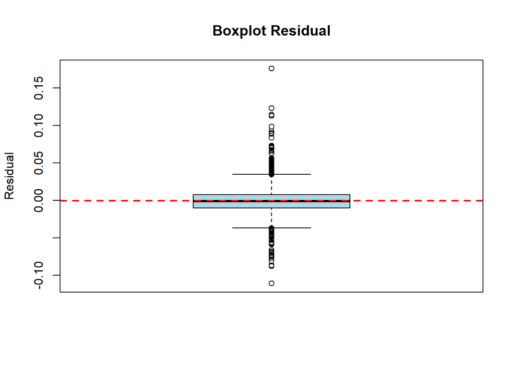

```r
boxplot(Res.Close517, main = "Boxplot Residual", ylab = "Residual", col = "lightblue", border = "black")
abline(h = mean(Res.Close517), col = "red", lwd = 2, lty = 2)  # Garis putus-putus merah di mean
```

```r
skewness(Res.Close517)  # Jika jauh dari 0, kemungkinan butuh sstd
```

```
## [1] 0.7099725
```

## ACF Residual

Untuk memerika asumsi kebebasan derau (noise), kita bisa memeriksa fungsi autokorelasi sampel residual.

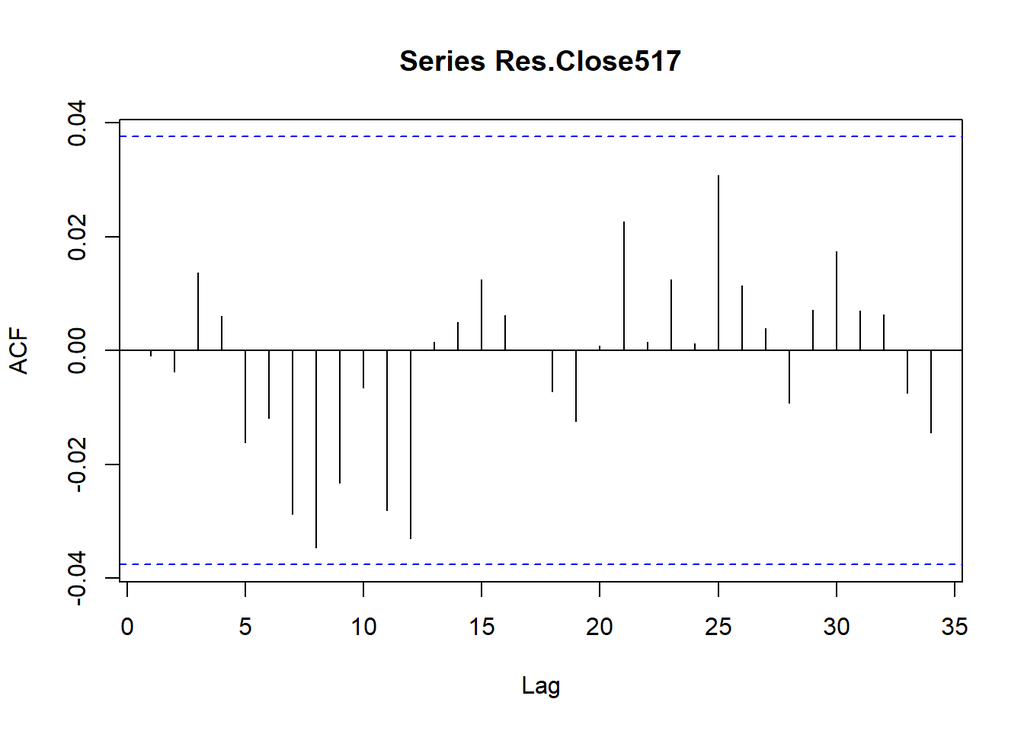

```r
acf(Res.Close517)
```

Berdasarkan plot fungsi autokorelasi sampel terlihat bahwa tidak ada yang melewati batas garis putus-putus.

## Menghitung nilai Ljung-Box

```r
ljung_box517 <- Box.test(Res.Close517, lag = 25, type = "Ljung-Box")
ljung_box517
```

```
##
##  Box-Ljung test
##
## data:  Res.Close517
## X-squared = 19.601, df = 25, p-value = 0.7675
```

Berdasarkan analisis Box-Ljung test, dimana nilai P-value (0.7675) lebih besar dari α=5%. Jadi dapat disimpulkan bahwa residual tidak berautokorelasi. Sehingga, asumsi non-autokorelasi terpenuhi.

## LJung-Box Statistik

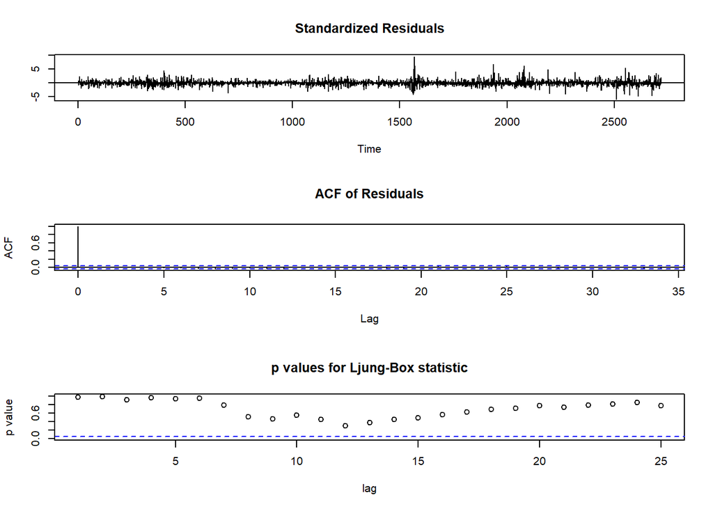

```r
tsdiag(Close.UNVRJK517, gof.lag =25)
```

Berdasarkan plot Ljung-Box terlihat bahwa tidak ada p-value yang berada di bawah garis putus-putus (nilai 0.05).

## Uji LM

```r
# Uji ARCH-LM pada standardized residuals
ArchTest(Res.Close517, lags = 10)
```

```
##
##  ARCH LM-test; Null hypothesis: no ARCH effects
##
## data:  Res.Close517
## Chi-squared = 255.83, df = 10, p-value < 2.2e-16
```

Pengecekan efek arch dilakukan dengan arch.test terhadap Close dan didapatkan nilai p-value 2.2e-16 yang berarti < alpha (0,05). Hal tersebut berarti menolak Ho (tidak ada efek arch) yang menandakan terdapat ada efek arch pada ARIMA (5,1,7)

# ARIMA (2,1,3)

## Plot Residual

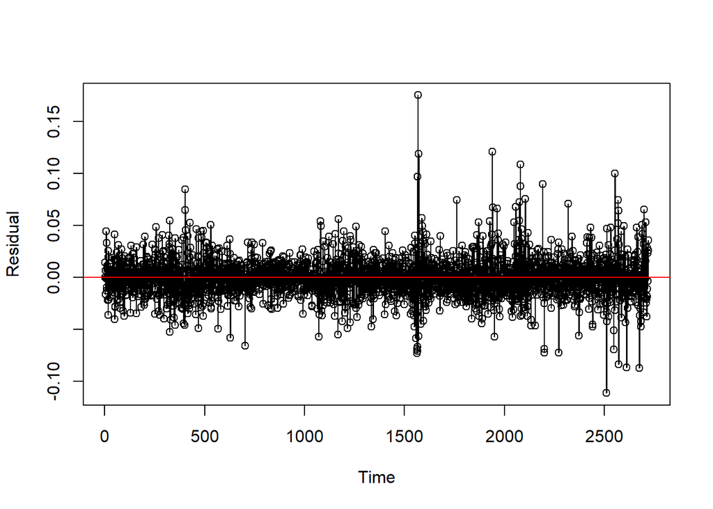

```r
Close.UNVRJK213 = arima(diff1.log.AP, order = c(2,1,3))
Res.Close213 = residuals(Close.UNVRJK213)
plot(Res.Close213, ylab = "Residual", type = "o")
abline(h=0, col = "red")
```

Pada output di atas terlihat plot residual yang mempermudah kita untuk melihat residual yang tidak wajar. Berdasarkan plot di atas terlihat bahwa tidak terdapat tren pada residual.

## Plot Kuantil Kenormalan

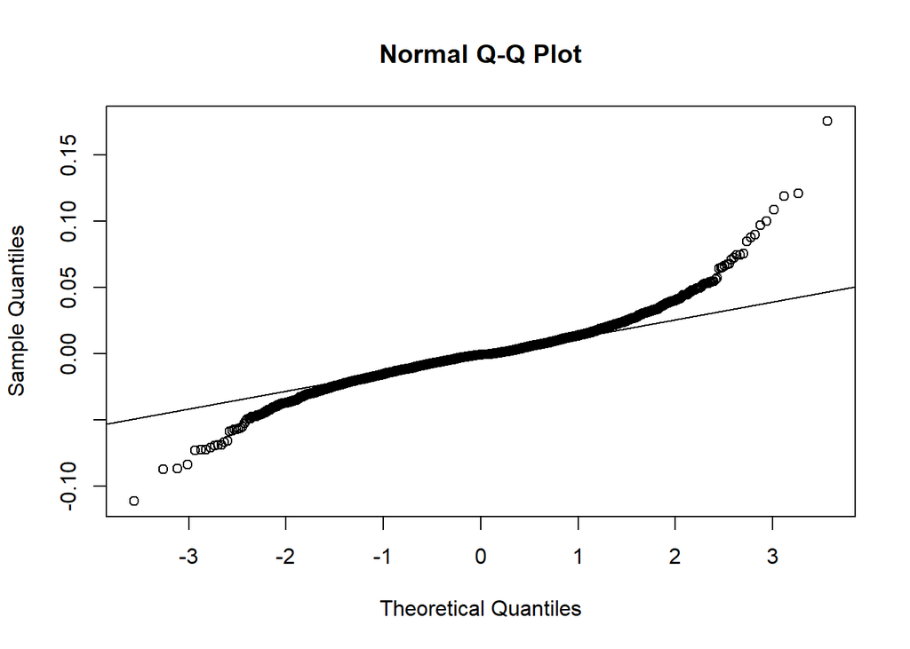

```r
qqnorm(Res.Close213)
qqline(Res.Close213)
```

Berdasarkan plot kuantil kenormalan terlihat bahwa beberapa titik berada di luar garis kuantil-kuantil.

## Uji Kolmogorov-Smirnov Test

```r
ks.test(Res.Close213, "pnorm", mean=mean(Res.Close213), sd=sd(Res.Close213))
```

```
##
##  Asymptotic one-sample Kolmogorov-Smirnov test
##
## data:  Res.Close213
## D = 0.077949, p-value = 9.104e-15
## alternative hypothesis: two-sided
```

Karena nilai p-value (9.104e-15) < α=5%, maka H0 ditolak. Artinya, dapat disimpulkan bahwa residual tidak mengikuti distribusi normal. Sehingga, asumsi normalitas tidak terpenuhi.

```r
kurtosis(Res.Close213)
```

```
## [1] 10.35838
```

Nilai kurtosis residual (Res.Close) yang kamu dapatkan adalah 10.35838, yang jauh lebih besar dari 3. Ini berarti distribusi residualnya leptokurtic (lebih runcing dari distribusi normal), yang menunjukkan bahwa data memiliki lebih banyak outlier dibanding distribusi normal.

```r
skewness(Res.Close213)  # Jika jauh dari 0, kemungkinan butuh sstd
```

```
## [1] 0.7273933
```

## ACF Residual

Untuk memerika asumsi kebebasan derau (noise), kita bisa memeriksa fungsi autokorelasi sampel residual.

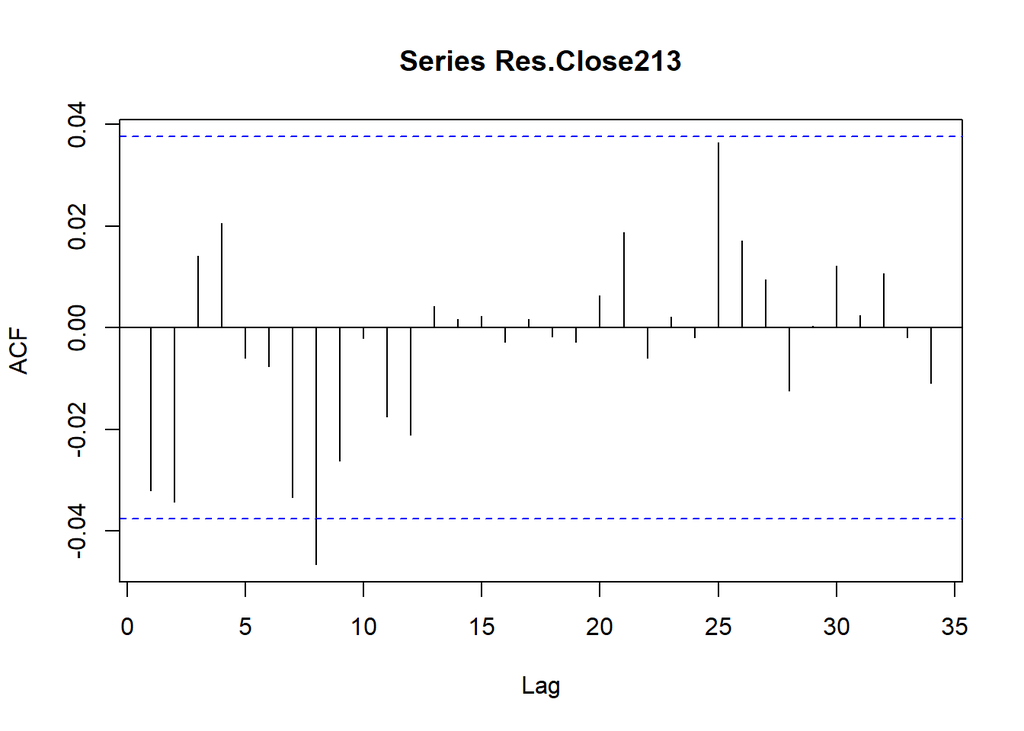

```r
acf(Res.Close213)
```

Berdasarkan plot fungsi autokorelasi sampel terlihat bahwa ada yang melewati batas garis putus-putus. Dengan demikian, dapat dikatakan bahwa terdapat autokorelasi pada residual.

## Menghitung nilai Ljung-Box

```r
ljung_box213 <- Box.test(Res.Close213, lag = 25, type = "Ljung-Box")
ljung_box213
```

```
##
##  Box-Ljung test
##
## data:  Res.Close213
## X-squared = 25.82, df = 25, p-value = 0.4173
```

Berdasarkan analisis Box-Ljung test, dimana nilai P-value (0.4173) lebih besar dari α=5%. Jadi dapat disimpulkan bahwa residual tidak berautokorelasi. Sehingga, asumsi non-autokorelasi terpenuhi.

## LJung-Box Statistik

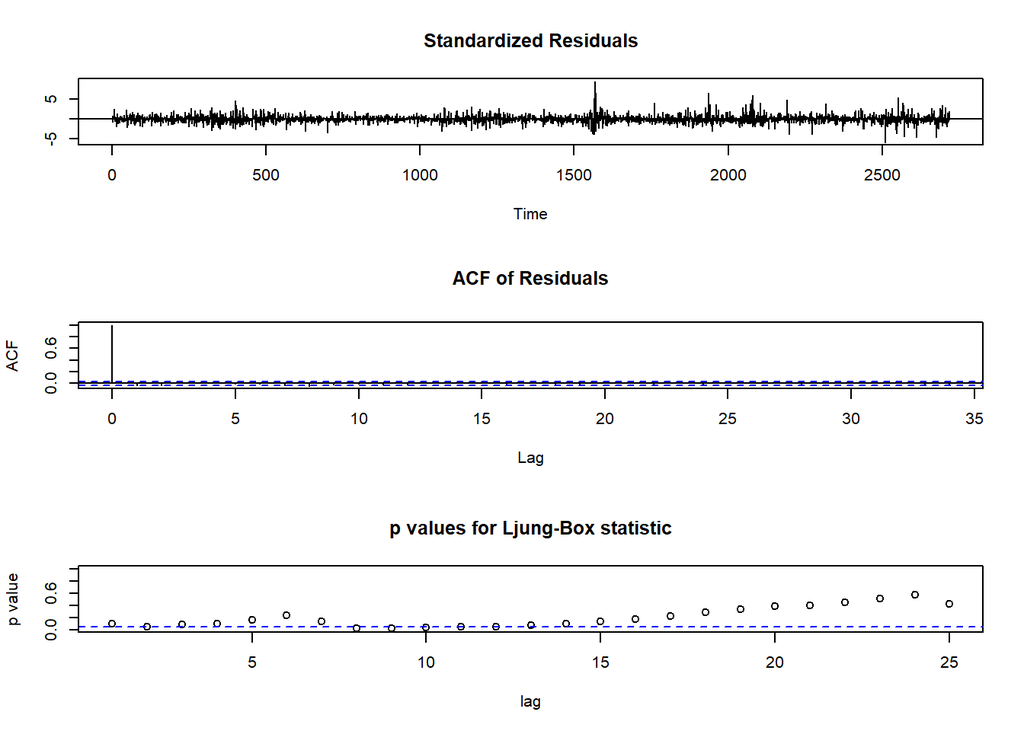

```r
tsdiag(Close.UNVRJK213, gof.lag =25)
```

Berdasarkan plot Ljung-Box terlihat bahwa ada p-value yang berada di bawah garis putus-putus (nilai 0.05).

## Uji LM

```r
# Uji ARCH-LM pada standardized residuals
ArchTest(Res.Close213, lags = 10)
```

```
##
##  ARCH LM-test; Null hypothesis: no ARCH effects
##
## data:  Res.Close213
## Chi-squared = 275.96, df = 10, p-value < 2.2e-16
```

Pengecekan efek arch dilakukan dengan arch.test terhadap Close dan didapatkan nilai p-value 2.2e-16 yang berarti < alpha (0,05). Hal tersebut berarti menolak Ho (tidak ada efek arch) yang menandakan terdapat ada efek arch pada ARIMA (2,1,3).

# ARIMA (2,1,13)

## Plot Residual

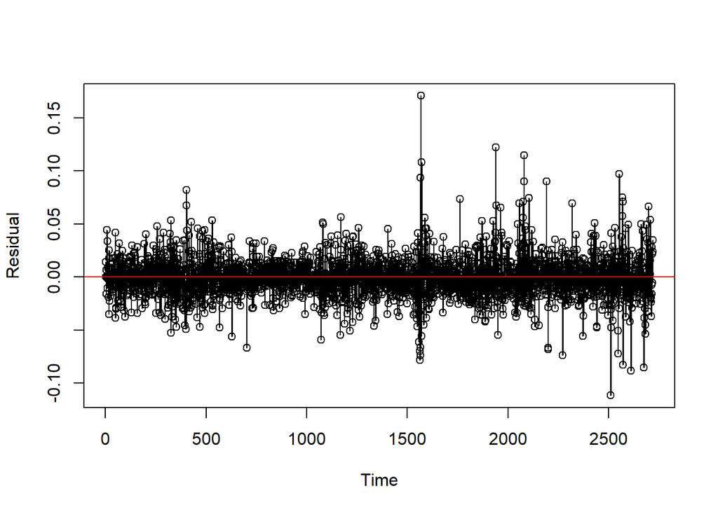

```r
Close.UNVRJK2113 = arima(diff1.log.AP, order = c(2,1,13))
Res.Close2113 = residuals(Close.UNVRJK2113)
plot(Res.Close2113, ylab = "Residual", type = "o")
abline(h=0, col = "red")
```

Pada output di atas terlihat plot residual yang mempermudah kita untuk melihat residual yang tidak wajar. Berdasarkan plot di atas terlihat bahwa tidak terdapat tren pada residual.

## Plot Kuantil Kenormalan

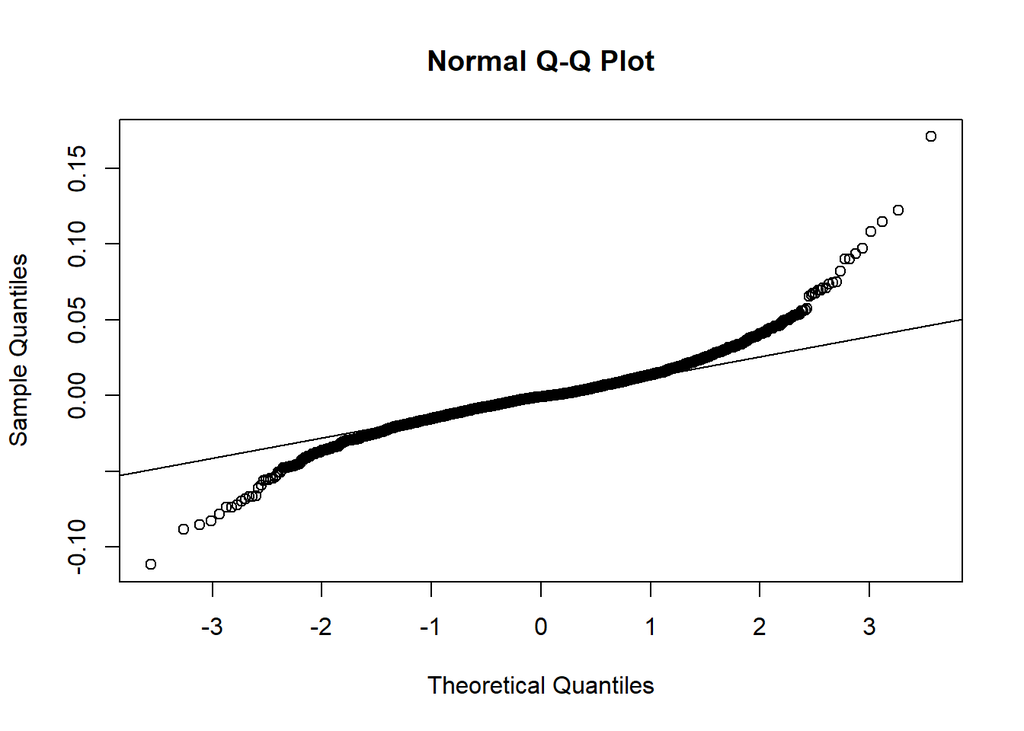

```r
qqnorm(Res.Close2113)
qqline(Res.Close2113)
```

Berdasarkan plot kuantil kenormalan terlihat bahwa beberapa titik berada di luar garis kuantil-kuantil.

## Uji Kolmogorov-Smirnov Test

```r
ks.test(Res.Close2113, "pnorm", mean=mean(Res.Close2113), sd=sd(Res.Close2113))
```

```
##
##  Asymptotic one-sample Kolmogorov-Smirnov test
##
## data:  Res.Close2113
## D = 0.075686, p-value = 5.984e-14
## alternative hypothesis: two-sided
```

Karena nilai p-value (5.984e-14) < α=5%, maka H0 ditolak. Artinya, dapat disimpulkan bahwa residual tidak mengikuti distribusi normal. Sehingga, asumsi normalitas tidak terpenuhi.

```r
kurtosis(Res.Close2113)
```

```
## [1] 10.12094
```

Nilai kurtosis residual (Res.Close) yang kamu dapatkan adalah 10.12094, yang jauh lebih besar dari 3. Ini berarti distribusi residualnya leptokurtic (lebih runcing dari distribusi normal), yang menunjukkan bahwa data memiliki lebih banyak outlier dibanding distribusi normal.

```r
skewness(Res.Close2113)  # Jika jauh dari 0, kemungkinan butuh sstd
```

```
## [1] 0.6893206
```

## ACF Residual

Untuk memerika asumsi kebebasan derau (noise), kita bisa memeriksa fungsi autokorelasi sampel residual.

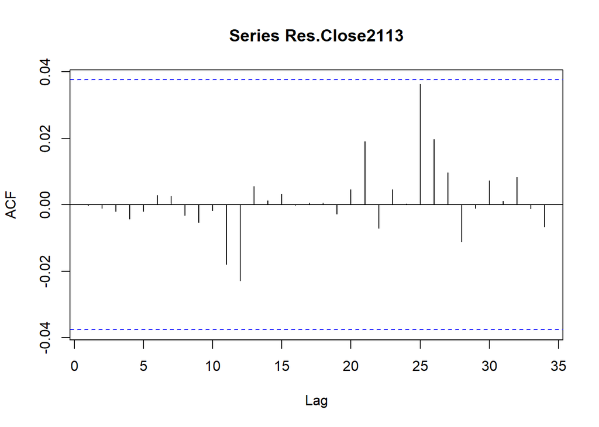

```r
acf(Res.Close2113)
```

Berdasarkan plot fungsi autokorelasi sampel terlihat bahwa tidak ada yang melewati batas garis putus-putus.

## Menghitung nilai Ljung-Box

```r
ljung_box2113 <- Box.test(Res.Close2113, lag = 25, type = "Ljung-Box")
ljung_box2113
```

```
##
##  Box-Ljung test
##
## data:  Res.Close2113
## X-squared = 7.5411, df = 25, p-value = 0.9997
```

Berdasarkan analisis Box-Ljung test, dimana nilai P-value (0.9997) lebih besar dari α=5%. Jadi dapat disimpulkan bahwa residual tidak berautokorelasi. Sehingga, asumsi non-autokorelasi terpenuhi.

## LJung-Box Statistik

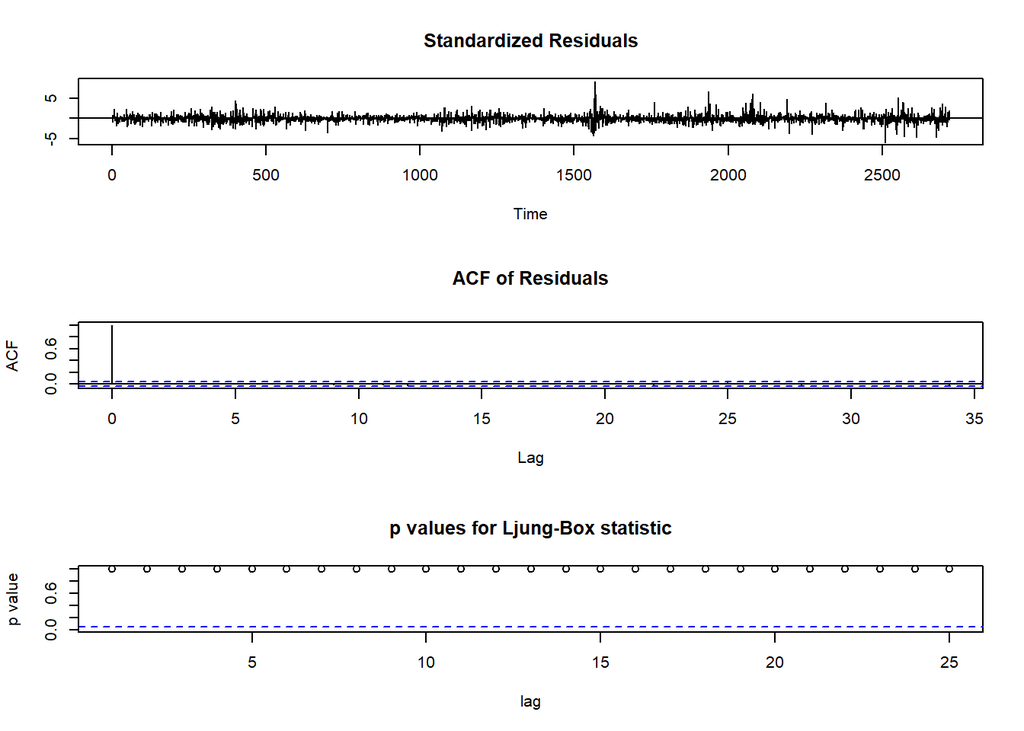

```r
tsdiag(Close.UNVRJK2113, gof.lag =25)
```

Berdasarkan plot Ljung-Box terlihat bahwa tidak ada p-value yang berada di bawah garis putus-putus (nilai 0.05).

## Uji LM

```r
# Uji ARCH-LM pada standardized residuals
ArchTest(Res.Close2113, lags = 10)
```

```
##
##  ARCH LM-test; Null hypothesis: no ARCH effects
##
## data:  Res.Close2113
## Chi-squared = 248.2, df = 10, p-value < 2.2e-16
```

Pengecekan efek arch dilakukan dengan arch.test terhadap Close dan didapatkan nilai p-value 2.2e-16 yang berarti < alpha (0,05). Hal tersebut berarti menolak Ho (tidak ada efek arch) yang menandakan terdapat ada efek arch pada ARIMA (2,1,13)